# Istatistiksel Yazilimlar Vize

Irem Koyunlu(121517056)Busra Caliskan(121517063)

26 05 2020

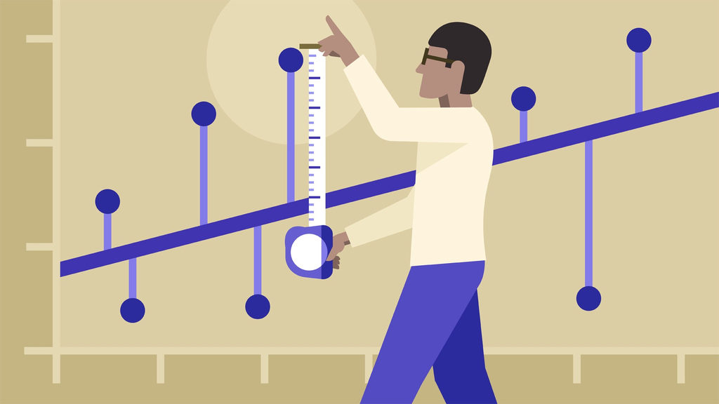

```r
library(summarytools) #tanimlayici istatistikler icin veri ozetleme
library(dplyr)
library(ggplot2)
library(MASS)
library(broom)
library(lubridate)
library(gridExtra)
library(GGally)
library(tidymodels)
library(caret)  #tum modeli karsilastirmak ve olusturmak icin kullanilir.
library(AmesHousing) #veri seti
library(ISLR)  #kitabin kutuphanesi
library(LogisticDx) #lojistik regresyon modelinin varsayimlari icin
library(pscl) #lojistik regresyon modeli icin uyum iyiligi istatistikleri
library(rpart)   #karar agaclari icin
library(summarytools) #tanimlayici istatistikleri cikarir.
library(e1071)  #confession matrisini elde etmek icin kullanilir.
library(tree) #karar agaclari icin
library(mdsr)  #Modern Data Science with R kitabi icin
library(rpart.plot)
library(C50)    #Baska agac tahmin etmek icin kullanilan paket
library(rattle)  #daha guzel karar agaci cizimi icin gerekli olan paket
library(party)
library(partykit)
#library(RWeka)
library(randomForest)
library(ROCR)
library(Metrics)
library(recipes)
library(modeldata)
library(themis) #undersampling ve oversampling icin kullanilan paket
library(ggplot2)
library(summarytools) #tanimlayici istatistikler icin
library(LogisticDx) #lojistik regresyon modelinin varsaimlari icin
library(pscl)
```

# Veri seti

Modellerin 2010’dan once satilan evlerde egitilmesi ve 2010’da satilan evlerde degerlendirilmesi gerekmektedir.

```r
######library(faraway)
####knitr::include_graphics("resim.jpg")
```

Kaynak: https://www.kaggle.com/c/house-prices-advanced-regression-techniques/overview

- SalePrice : Mulkun satis fiyati dolar. Bu, tahmin etmeye calistiginiz hedef degiskendir.
- MSSubClass: Yapi sinifi
- MSZoning: Genel imar siralamasi
- LotFrontage: Mulke bagli sokak uzunlugu
- LotArea: Metrekare cinsten lot buyuklugu
- Street: Yol erisim turu
- Alley: Alley erisim turu
- LotShape: Mulkun Genel sekli
- LandContour: Mulkun duzlugu
- Utilities: Uygun program turu
- LotConfig: Lot yapilandirma
- LandSlope: Mulkiyet egimi
- Neighborhood : Ames sehir sinirlari icinde fiziksel lokasyonlari
- Condition1: Ana yola veya demiryoluna yakinlik
- Condition2: Ana yola veya demiryoluna yakinlik (eger bir saniye varsa)
- BldgType: Konut turu
- HouseStyle: Konut tarzi
- OverallQual: Genel malzeme ve bitis kalitesi
- OverallCond: Genel durum degerlendirmesi
- YearBuilt: orijinal insaat tarihi(binanin yasi)
- YearRemodAdd: tadilat tarihi
- RoofStyle: Cati tipi
- RoofMatl: Cati malzemesi
- Exterior1st: Evde dis kaplama
- Exterior2nd: Evde dis kaplama (birden fazla malzeme varsa)
- MasVnrType: Duvar kaplama tipi
- MasVnrArea: Metre kare duvar kaplama alani
- ExterQual: Dis malzeme kalitesi
- ExterCond: Dis malzemenin mevcut durumu
- Foundation : Vakif turu
- Bsmtqual: Bodrum yuksekligi
- Bsmtcond: Bodrumun genel durumu
- Bsmtexposure: Cikis veya bahce seviyesi Bodrum duvarlari
- Bsmtfıntype1: Bodrum bitmis alanin kalitesi
- Bsmtfınsf1: Tip 1 bitmis metre kare
- Bsmtfıntype2: ikinci bitmis alanin kalitesi (varsa)
- Bsmtfınsf2: Tip 2 bitmis metre kare
- Bsmtunfsf: Bodrum alaninin bitmemis feet Kare
- TotalBsmtSF: Bodrum alaninin toplam metre kare
- Heating: Isitma tipi
- HeatingQC: Isıtma kalitesi ve durumu
- Centrallair: Merkezi Klima
- Electrical: Elektrik sistemi
- onestflrsf: Birinci kat metre kare
- twondFlrSF: Ikinci kat metre kare
- LowQualFinSF: Dusuk kaliteli bitmis metre kare (tüm zeminler)
- GrLivArea: Yukaridaki sinif (zemin) oturma alani metre kare
- Bsmtfullbath: Bodrum tam banyolar
- Bsmthalfbath: Bodrum yarim banyo
- FullBath: Kalite ustu tam banyolar
- HalfBath: Kalite uzerinde yarim banyolar
- Bedroom: Bodrum katinin uzerindeki yatak odasi sayisi
- Kitchen : Mutfak sayisi
- KitchenQual: Mutfak kalitesi
- TotRmsAbvGrd: Kalite uzerinde toplam oda (banyo icermez)
- Functional: Ev islevselligi degerlendirmesi
- Fireplaces : Somine sayisi
- FireplaceQu: Somine kalitesi
- GarageType: Garaj tipi
- GarageYrBlt: Garajin insa edildigi yil
- GarageFinish: Garajin ic kaplamasi
- GarageCars: Garajin araba kapasitesi
- GarageArea: Garajin metre kare cinsinden boyutu
- GarageQual: Garaj kalitesi
- GarageCond: Garaj durumu
- PavedDrive: Evin onundeki ozel araba yolu
- WoodDeckSF: Metre kare ahsap guverte alani
- OpenPorchSF: Metre kare acik sundurma alani
- EnclosedPorch: Metre kare kapali sundurma alani
- 3SsnPorch: Uc sezon sundurma alani metre kare
- ScreenPorch: Metrekare ekran sundurma alani
- PoolArea: Metre kare havuz alani
- PoolQC: Havuz kalitesi
- Fence: Cit kalitesi
- MiscFeature: Diger kategorilerde yer almayan cesitli ozellik
- MiscVal :Cesitli ozellik $ degeri
- MoSold: Aylik satilan ev
- YrSold: Yillik satilan ev
- SaleType: Satis türü
- SaleCondition: Satis durumu

Daha fazla bilgi için: http://jse.amstat.org/v19n3/decock.pdf

https://www.kaggle.com/leeclemmer/exploratory-data-analysis-of-housing-in-ames-iowa

```r
library(AmesHousing)
#ames_raw
```

Oncelikle verimizin degisken isimlerini degistiriyoruz. Verimizi daha kolay kullanabilmek icin adini degistirdik.

```r
data <- ames_raw
colnames(data) <- c("Order", "PID","MSSubClass","MSZoning","LotFrontage","LotArea","Street","Alley","LotShape","LandContour","Utilities","LotConfig","LandSlope","Neighborhood","Condition1","Condition2","BldgType","HouseStyle","OverallQual","OverallCond","YearBuilt","YearRemodAdd","RoofStyle","RoofMatl","Exterior1","Exterior2","MasVnrType","MasVnrArea","ExterQual","ExterCond","Foundation","BsmtQual","BsmtCond","BsmtExposure","BsmtFinType1","BsmtFinSF1","BsmtFinType2","BsmtFinSF2","BsmtUnfSF","TotalBsmtSF","Heating","HeatingQC","CentralAir","Electrical","OnestFlrSF","TwondFlrSF","LowQualFinSF","GrLivArea","BsmtFullBath","BsmtHalfBath","FullBath","HalfBath","Bedroom","Kitchen","KitchenQual","TotRmsAbvGrd","Functional","Fireplaces","FireplaceQu","GarageType","GarageYrBlt","GarageFinish","GarageCars","GarageArea","GarageQual","GarageCond","PavedDrive","WoodDeckSF","OpenPorchSF","EnclosedPorch","ThreeSsnPorch","ScreenPorch","PoolArea","PoolQC","Fence","MiscFeature","MiscVal","MoSold","YrSold","SaleType","SaleCondition","SalePrice")
```

Oncelikle verimizi ozetleyelim.

```r
summary(data)
```

```
##      Order            PID             MSSubClass          MSZoning
##  Min.   :   1.0   Length:2930        Length:2930        Length:2930
##  1st Qu.: 733.2   Class :character   Class :character   Class :character
##  Median :1465.5   Mode  :character   Mode  :character   Mode  :character
##  Mean   :1465.5
##  3rd Qu.:2197.8
##  Max.   :2930.0
##
##   LotFrontage        LotArea          Street             Alley
##  Min.   : 21.00   Min.   :  1300   Length:2930        Length:2930
##  1st Qu.: 58.00   1st Qu.:  7440   Class :character   Class :character
##  Median : 68.00   Median :  9436   Mode  :character   Mode  :character
##  Mean   : 69.22   Mean   : 10148
##  3rd Qu.: 80.00   3rd Qu.: 11555
##  Max.   :313.00   Max.   :215245
##  NA's   :490
##    LotShape         LandContour         Utilities          LotConfig
##  Length:2930        Length:2930        Length:2930        Length:2930
##  Class :character   Class :character   Class :character   Class :character
##  Mode  :character   Mode  :character   Mode  :character   Mode  :character
##
##
##
##
##   LandSlope         Neighborhood        Condition1         Condition2
##  Length:2930        Length:2930        Length:2930        Length:2930
##  Class :character   Class :character   Class :character   Class :character
##  Mode  :character   Mode  :character   Mode  :character   Mode  :character
##
##
##
##
##    BldgType          HouseStyle         OverallQual      OverallCond
##  Length:2930        Length:2930        Min.   : 1.000   Min.   :1.000
##  Class :character   Class :character   1st Qu.: 5.000   1st Qu.:5.000
##  Mode  :character   Mode  :character   Median : 6.000   Median :5.000
##                                        Mean   : 6.095   Mean   :5.563
##                                        3rd Qu.: 7.000   3rd Qu.:6.000
##                                        Max.   :10.000   Max.   :9.000
##
```

[output cut: 113 more lines]

```
##  Min.   :    0.00   Min.   : 1.000   Min.   :2006   Length:2930
##  1st Qu.:    0.00   1st Qu.: 4.000   1st Qu.:2007   Class :character
##  Median :    0.00   Median : 6.000   Median :2008   Mode  :character
##  Mean   :   50.63   Mean   : 6.216   Mean   :2008
##  3rd Qu.:    0.00   3rd Qu.: 8.000   3rd Qu.:2009
##  Max.   :17000.00   Max.   :12.000   Max.   :2010
##
##  SaleCondition        SalePrice
##  Length:2930        Min.   : 12789
##  Class :character   1st Qu.:129500
##  Mode  :character   Median :160000
##                     Mean   :180796
##                     3rd Qu.:213500
##                     Max.   :755000
##
```

Verimizde order degiskenimizi faktor haline getirmeliyiz.

```r
data$Order <- factor(data$Order)
```

Verimiz de saleprice si 230000 den buyuk olanlari 1 ve 230000 kucuk olanlari 0 a atayip yeni bir degisken olarak veriye ekleyelim(salepricecat).

```r
data <- data %>% mutate( SalePricecat=ifelse(data$SalePrice>230000, "1","0" ))

data$SalePricecat <- factor(data$SalePricecat)
```

Ilerde lojistik regresyonda kullanabilmek icin yanit degiskenimizin 0 ve 1 degerlerini factor olarak atadik.

Verimizi test ve train olarak ikiye ayirdik.Modeller trainveri seti uzerinden kurulup test veri seti uzerinden denenecektir.

```r
set.seed(3014)
train=sample(1:2930, size=1460, replace=F)
traindata<-data[train,]
testdata<-data[-train,]
```

```r
str(data)
```

```
## tibble [2,930 x 83] (S3: tbl_df/tbl/data.frame)
##  $ Order        : Factor w/ 2930 levels "1","2","3","4",..: 1 2 3 4 5 6 7 8 9 10 ...
##  $ PID          : chr [1:2930] "0526301100" "0526350040" "0526351010" "0526353030" ...
##  $ MSSubClass   : chr [1:2930] "020" "020" "020" "020" ...
##  $ MSZoning     : chr [1:2930] "RL" "RH" "RL" "RL" ...
##  $ LotFrontage  : int [1:2930] 141 80 81 93 74 78 41 43 39 60 ...
##  $ LotArea      : int [1:2930] 31770 11622 14267 11160 13830 9978 4920 5005 5389 7500 ...
##  $ Street       : chr [1:2930] "Pave" "Pave" "Pave" "Pave" ...
##  $ Alley        : chr [1:2930] NA NA NA NA ...
##  $ LotShape     : chr [1:2930] "IR1" "Reg" "IR1" "Reg" ...
##  $ LandContour  : chr [1:2930] "Lvl" "Lvl" "Lvl" "Lvl" ...
##  $ Utilities    : chr [1:2930] "AllPub" "AllPub" "AllPub" "AllPub" ...
##  $ LotConfig    : chr [1:2930] "Corner" "Inside" "Corner" "Corner" ...
##  $ LandSlope    : chr [1:2930] "Gtl" "Gtl" "Gtl" "Gtl" ...
##  $ Neighborhood : chr [1:2930] "NAmes" "NAmes" "NAmes" "NAmes" ...
##  $ Condition1   : chr [1:2930] "Norm" "Feedr" "Norm" "Norm" ...
##  $ Condition2   : chr [1:2930] "Norm" "Norm" "Norm" "Norm" ...
##  $ BldgType     : chr [1:2930] "1Fam" "1Fam" "1Fam" "1Fam" ...
##  $ HouseStyle   : chr [1:2930] "1Story" "1Story" "1Story" "1Story" ...
##  $ OverallQual  : int [1:2930] 6 5 6 7 5 6 8 8 8 7 ...
##  $ OverallCond  : int [1:2930] 5 6 6 5 5 6 5 5 5 5 ...
##  $ YearBuilt    : int [1:2930] 1960 1961 1958 1968 1997 1998 2001 1992 1995 1999 ...
##  $ YearRemodAdd : int [1:2930] 1960 1961 1958 1968 1998 1998 2001 1992 1996 1999 ...
##  $ RoofStyle    : chr [1:2930] "Hip" "Gable" "Hip" "Hip" ...
##  $ RoofMatl     : chr [1:2930] "CompShg" "CompShg" "CompShg" "CompShg" ...
##  $ Exterior1    : chr [1:2930] "BrkFace" "VinylSd" "Wd Sdng" "BrkFace" ...
##  $ Exterior2    : chr [1:2930] "Plywood" "VinylSd" "Wd Sdng" "BrkFace" ...
##  $ MasVnrType   : chr [1:2930] "Stone" "None" "BrkFace" "None" ...
##  $ MasVnrArea   : int [1:2930] 112 0 108 0 0 20 0 0 0 0 ...
##  $ ExterQual    : chr [1:2930] "TA" "TA" "TA" "Gd" ...
##  $ ExterCond    : chr [1:2930] "TA" "TA" "TA" "TA" ...
##  $ Foundation   : chr [1:2930] "CBlock" "CBlock" "CBlock" "CBlock" ...
##  $ BsmtQual     : chr [1:2930] "TA" "TA" "TA" "TA" ...
##  $ BsmtCond     : chr [1:2930] "Gd" "TA" "TA" "TA" ...
##  $ BsmtExposure : chr [1:2930] "Gd" "No" "No" "No" ...
##  $ BsmtFinType1 : chr [1:2930] "BLQ" "Rec" "ALQ" "ALQ" ...
##  $ BsmtFinSF1   : int [1:2930] 639 468 923 1065 791 602 616 263 1180 0 ...
##  $ BsmtFinType2 : chr [1:2930] "Unf" "LwQ" "Unf" "Unf" ...
##  $ BsmtFinSF2   : int [1:2930] 0 144 0 0 0 0 0 0 0 0 ...
##  $ BsmtUnfSF    : int [1:2930] 441 270 406 1045 137 324 722 1017 415 994 ...
```

[output cut: 114 more lines]

```
##   ..   `Open Porch SF` = col_integer(),
##   ..   `Enclosed Porch` = col_integer(),
##   ..   `3Ssn Porch` = col_integer(),
##   ..   `Screen Porch` = col_integer(),
##   ..   `Pool Area` = col_integer(),
##   ..   `Pool QC` = col_character(),
##   ..   Fence = col_character(),
##   ..   `Misc Feature` = col_character(),
##   ..   `Misc Val` = col_integer(),
##   ..   `Mo Sold` = col_integer(),
##   ..   `Yr Sold` = col_integer(),
##   ..   `Sale Type` = col_character(),
##   ..   `Sale Condition` = col_character(),
##   ..   SalePrice = col_integer()
##   .. )
```

Str kodu ile baktigimizda modelimizdeki degiskenlerimiz dogru tanimlanmistir.

# Soru 1: Regresyon

Amaç aşağıdaki test kümesini minimum **Kök logaritmik hata kareler ortalamasını** verecek şekilde tahmin etmektir. Derste öğrenilen modeller denenmelidir. Bunlar dışında istediğiniz modeli kullanabilirsiniz.

Oncelikle klasik lineer modelimizi olusturduk.

```r
lmod1<-lm(SalePrice ~ OverallQual+
             LotFrontage+
             LotArea+
             OverallCond+
             Kitchen+
             TotRmsAbvGrd+
             OnestFlrSF+
             GrLivArea+
             MoSold+
             GarageCars,data=traindata)
summary(lmod1)
```

```
##
## Call:
## lm(formula = SalePrice ~ OverallQual + LotFrontage + LotArea +
##     OverallCond + Kitchen + TotRmsAbvGrd + OnestFlrSF + GrLivArea +
##     MoSold + GarageCars, data = traindata)
##
## Residuals:
##     Min      1Q  Median      3Q     Max
## -361450  -19364   -1259   17755  221333
##
## Coefficients:
##                Estimate Std. Error t value Pr(>|t|)
## (Intercept)  -9.939e+04  1.006e+04  -9.883  < 2e-16 ***
## OverallQual   2.476e+04  1.041e+03  23.791  < 2e-16 ***
## LotFrontage   8.911e+01  5.407e+01   1.648   0.0996 .
## LotArea       7.098e-01  1.534e-01   4.626 4.13e-06 ***
## OverallCond   1.579e+03  9.746e+02   1.620   0.1055
## Kitchen      -2.740e+04  5.260e+03  -5.210 2.22e-07 ***
## TotRmsAbvGrd -8.244e+02  1.237e+03  -0.667   0.5051
## OnestFlrSF    3.852e+01  3.696e+00  10.421  < 2e-16 ***
## GrLivArea     4.732e+01  4.318e+00  10.959  < 2e-16 ***
## MoSold       -3.835e+02  3.719e+02  -1.031   0.3026
## GarageCars    1.607e+04  1.798e+03   8.937  < 2e-16 ***
## ---
## Signif. codes:  0 '***' 0.001 '**' 0.01 '*' 0.05 '.' 0.1 ' ' 1
##
## Residual standard error: 35250 on 1201 degrees of freedom
##   (248 observations deleted due to missingness)
## Multiple R-squared:  0.8133, Adjusted R-squared:  0.8118
## F-statistic: 523.3 on 10 and 1201 DF,  p-value: < 2.2e-16
```

```r
sqrt(35250) #Residual standard error in karekoku RMSE verir
```

```
## [1] 187.7498
```

```r
lmod<-lm(SalePrice ~ OverallQual+
             LotArea+
            YearRemodAdd+
             OnestFlrSF+
             GrLivArea+
            GarageCars,data=traindata)
summary(lmod)
```

```
##
## Call:
## lm(formula = SalePrice ~ OverallQual + LotArea + YearRemodAdd +
##     OnestFlrSF + GrLivArea + GarageCars, data = traindata)
##
## Residuals:
##     Min      1Q  Median      3Q     Max
## -341351  -18643    -544   17766  229501
##
## Coefficients:
##                Estimate Std. Error t value Pr(>|t|)
## (Intercept)  -9.758e+05  1.036e+05  -9.416  < 2e-16 ***
## OverallQual   2.278e+04  9.587e+02  23.762  < 2e-16 ***
## LotArea       7.264e-01  1.135e-01   6.399 2.10e-10 ***
## YearRemodAdd  4.440e+02  5.350e+01   8.299 2.38e-16 ***
## OnestFlrSF    3.915e+01  3.020e+00  12.962  < 2e-16 ***
## GrLivArea     4.117e+01  2.421e+00  17.005  < 2e-16 ***
## GarageCars    1.268e+04  1.599e+03   7.929 4.38e-15 ***
## ---
## Signif. codes:  0 '***' 0.001 '**' 0.01 '*' 0.05 '.' 0.1 ' ' 1
##
## Residual standard error: 34180 on 1453 degrees of freedom
## Multiple R-squared:  0.8098, Adjusted R-squared:  0.809
## F-statistic:  1031 on 6 and 1453 DF,  p-value: < 2.2e-16
```

Logaritma almak birbirinden ayri degerleri birbirine yakinlastirmak icin yapilan bir islemdir.

$$\sqrt{\frac{1}{n}\sum_{i=1}^n (log(\widehat{y_i} + 1)- log({y_i}+ 1))^2}$$

```r
set.seed(3014)
rmlse <- function(model) {
  y <-abs( traindata$SalePrice)
  y.pred <- abs(predict(model, traindata))
  return(sqrt(1/length(y)*sum((log(y.pred +1)-log(traindata$SalePrice +1))^2)))
}
rmlse(lmod)
```

```
## [1] 0.2524022
```

```r
sqrt(34180) #Residual standard error in karekoku RMSE verir
```

```
## [1] 184.8783
```

# Karar Agaci

Bagimsiz degiskenimiz salepricenin logaritmasini almak ev fiyatlarimizi birbirlerine yaklastirir.

```r
set.seed(3014)
require(tree)
treefit <- tree(SalePrice ~ GrLivArea + GarageArea, data = traindata)
summary(treefit)
```

```
##
## Regression tree:
## tree(formula = SalePrice ~ GrLivArea + GarageArea, data = traindata)
## Number of terminal nodes:  8
## Residual mean deviance:  2.131e+09 = 3.095e+12 / 1452
## Distribution of residuals:
##      Min.   1st Qu.    Median      Mean   3rd Qu.      Max.
## -215100.0  -26750.0    -522.2       0.0   22670.0  244900.0
```

Number of terminal nodes agac yaprak sayisidir.Degerlere baktigimizda karar agacimiz 8 yaprakli olacaktir. Residual mean deviance yani Residual mean deviance degerimiz 2.131e+09 cikmistir.

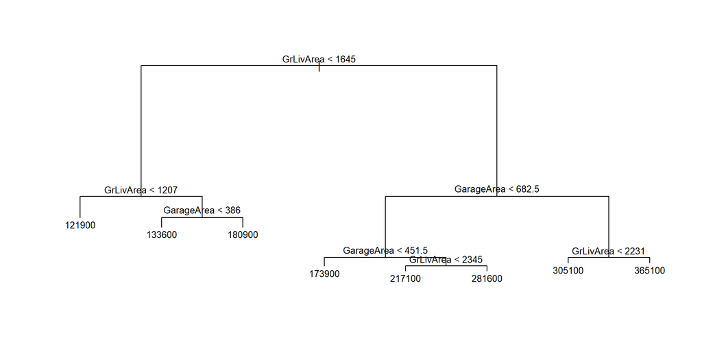

Regresyon agaci

Agacin uclari tahmin degerlerini verir. Karar agacinda da goruldugu uzere yukaridaki sonucumuz ile ayni cikmistir yani karar agacimiz 8 yapraklidir.

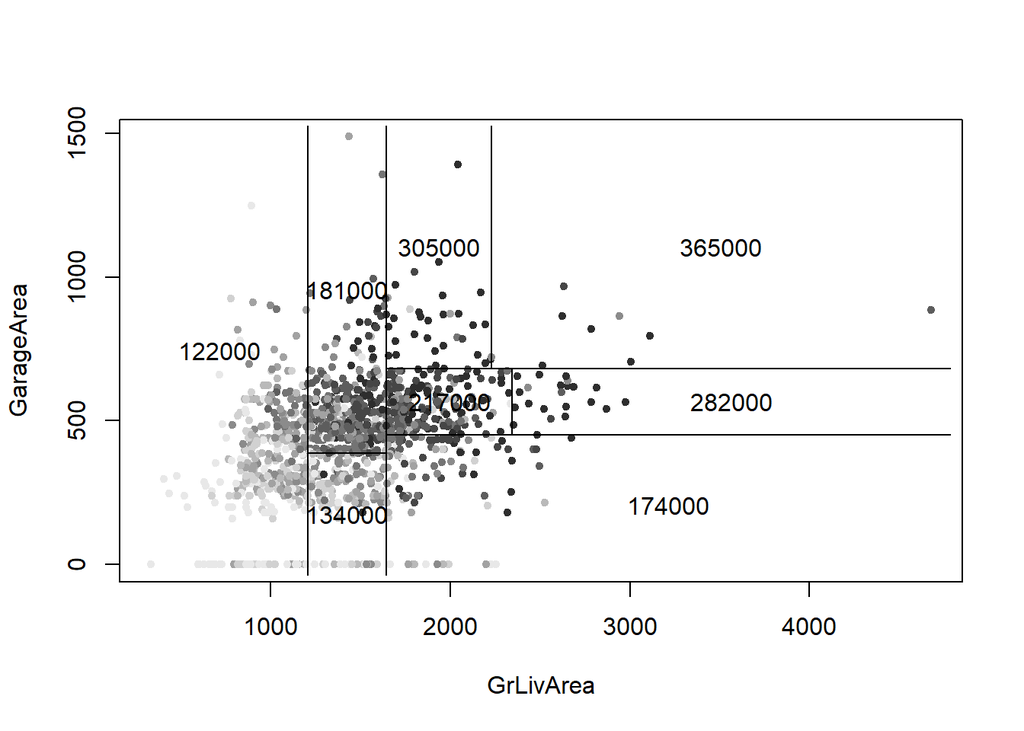

```r
set.seed(3014)
price.deciles <- quantile(traindata$SalePrice, 0:10/10) #bagimsiz degiskenimizin quartile i alinir.

cut.prices <- cut(traindata$SalePrice, price.deciles, include.lowest = TRUE) #ev fiyatlarinin quartile lerinin kesim notlari

plot(traindata$GrLivArea, traindata$GarageArea, col = grey(10:2/11)[cut.prices], pch = 20,
xlab = "GrLivArea", ylab = "GarageArea")

partition.tree(treefit, ordvars = c("GrLivArea", "GarageArea"), add = TRUE)
```

Koyu renkli notalar daha yuksekte olan ev fiyatlarini gostermektedir. Grafikte de goruldugu uzere GrLivArea(Yukaridaki sinif (zemin) oturma alani metre kare) arttiginda GarageArea (Garajin metre kare cinsinden boyutu) de dogru orantili artmaktadir buna bagli olarak ev fiyatida artmistir.

Daha komplike bir agac icin daha kucuk bir mindev durdurma kriteri verilir.

```r
set.seed(3014)
treefit2 <- tree(log(SalePrice) ~ GrLivArea + GarageArea, data = traindata,
mindev = 0.001)
summary(treefit2)
```

```
##
## Regression tree:
## tree(formula = log(SalePrice) ~ GrLivArea + GarageArea, data = traindata,
##     mindev = 0.001)
## Number of terminal nodes:  40
## Residual mean deviance:  0.04748 = 67.43 / 1420
## Distribution of residuals:
##     Min.  1st Qu.   Median     Mean  3rd Qu.     Max.
## -1.62900 -0.10720  0.02026  0.00000  0.12470  0.74950
```

Residual mean deviance degerimiz 0.04748 cikmistir mindev = 0.001 alindiginda yaprak sayimiz artmistir. Daha kompleks bir hale donusmustur.mindev: tuning parameters

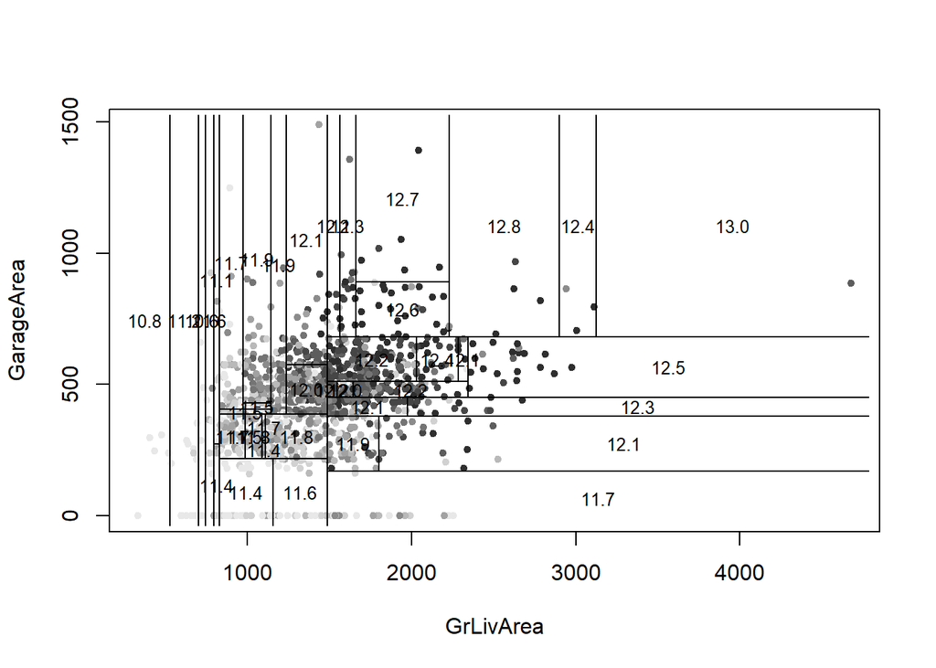

```r
set.seed(3014)
plot(traindata$GrLivArea, traindata$GarageArea, col = grey(10:2/11)[cut.prices], pch = 20,
xlab = "GrLivArea", ylab = "GarageArea")

partition.tree(treefit2, ordvars = c("GrLivArea", "GarageArea"), add = TRUE , cex = 0.8)
```

Grafikte de goruldugu uzere mindev=0.001 olacak sekilde alindiginda yaprak sayimiz arttigi icin over fit olmustur model kompleks hale donmustur.

# CART model building

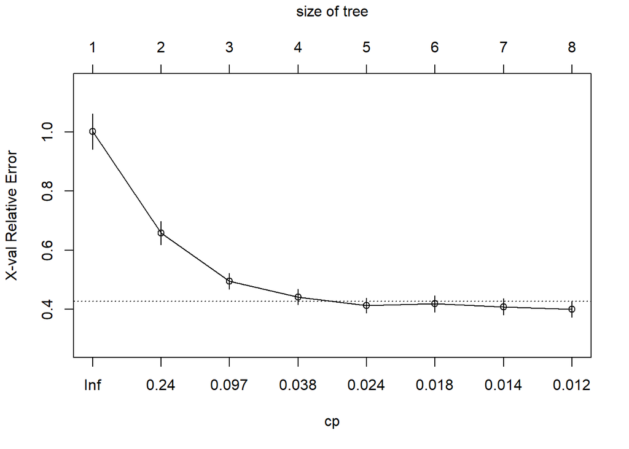

```r
set.seed(3014)
fit <- rpart(SalePrice~GrLivArea
             + GarageArea ,data=traindata)
#summary(fit)

#printcp(fit) # sonuçları göster
plotcp(fit) # capraz dogrulama sonuclarini gorsellestirir
```

```r
#summary(fit) #bolunmelerin ayrintili ozeti
```

Burada en dusuk complex parametere degeri secilir yani cp=0.012 dir.

# Agacin gorsellestirilmesi

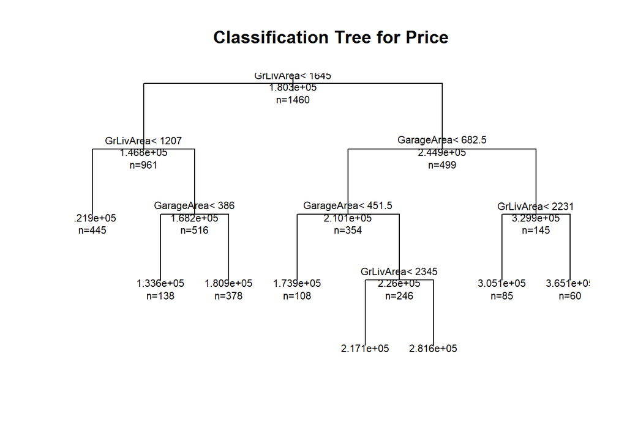

```r
set.seed(3014)
plot(fit, uniform=TRUE,
     main="Classification Tree for Price")
text(fit, use.n=TRUE, all=TRUE, cex=0.7)
```

[figure not shown]

```r
fancyRpartPlot(fit,main="Classification Tree for Price",col="red")  #budanmamis karar agacinin suslu halidir
```

```r
#farkli  bir gorsellestirme
#party.fit <- as.party(fit)
#plot(party.fit,main="Classification Tree for Price")
#text(fit, use.n=TRUE, all=TRUE, cex=0.5) #dallardaki kutu grafikleri kucuk gozuktugu icin calistirilmadi
```

# Karar agacinin budanmasi

```r
set.seed(3014)
pfit<- prune(fit, cp=fit$cptable[which.min(fit$cptable[,"xerror"]),"CP"])

# Bu kod, belirtilen cp degerine gore kurulacaktir.
pfit<- prune(fit, cp=0.05)

summary(pfit)
```

```
## Call:
## rpart(formula = SalePrice ~ GrLivArea + GarageArea, data = traindata)
##   n= 1460
##
##           CP nsplit rel error    xerror       xstd
## 1 0.35429504      0 1.0000000 1.0014996 0.06080363
## 2 0.16552508      1 0.6457050 0.6572967 0.03948202
## 3 0.05739263      2 0.4801799 0.4950949 0.02729591
## 4 0.05000000      3 0.4227873 0.4412726 0.02630500
##
## Variable importance
##  GrLivArea GarageArea
##         63         37
##
## Node number 1: 1460 observations,    complexity param=0.354295
##   mean=180328.2, MSE=6.11273e+09
##   left son=2 (961 obs) right son=3 (499 obs)
##   Primary splits:
##       GrLivArea  < 1645  to the left,  improve=0.3542950, (0 missing)
##       GarageArea < 675.5 to the left,  improve=0.3232701, (0 missing)
##   Surrogate splits:
##       GarageArea < 631.5 to the left,  agree=0.733, adj=0.218, (0 split)
##
## Node number 2: 961 observations,    complexity param=0.05739263
##   mean=146793.9, MSE=1.903947e+09
##   left son=4 (445 obs) right son=5 (516 obs)
##   Primary splits:
##       GrLivArea  < 1207  to the left,  improve=0.2799406, (0 missing)
##       GarageArea < 387   to the left,  improve=0.2775874, (0 missing)
##   Surrogate splits:
##       GarageArea < 368.5 to the left,  agree=0.669, adj=0.285, (0 split)
##
## Node number 3: 499 observations,    complexity param=0.1655251
##   mean=244910.2, MSE=7.881676e+09
##   left son=6 (354 obs) right son=7 (145 obs)
##   Primary splits:
##       GarageArea < 682.5 to the left,  improve=0.3756062, (0 missing)
##       GrLivArea  < 2232  to the left,  improve=0.1791641, (0 missing)
##   Surrogate splits:
##       GrLivArea < 2661  to the left,  agree=0.747, adj=0.131, (0 split)
##
## Node number 4: 445 observations
##   mean=121933.7, MSE=9.761703e+08
##
## Node number 5: 516 observations
##   mean=168233.4, MSE=1.711419e+09
##
## Node number 6: 354 observations
##   mean=210087.8, MSE=3.77367e+09
##
## Node number 7: 145 observations
##   mean=329924.7, MSE=7.722993e+09
```

Verilen MSE degerimizden RMSE degerini hesaplayalim

```r
sqrt(9.761703e+08)
```

```
## [1] 31243.72
```

cp degeri kuculdukce daha kompleks agaclar verir. Bu sebeple cp degerini hesaplayarak 0.05 alarak kompleksligi azalttik bulduk.

# Budanmis agacin cizilmesi

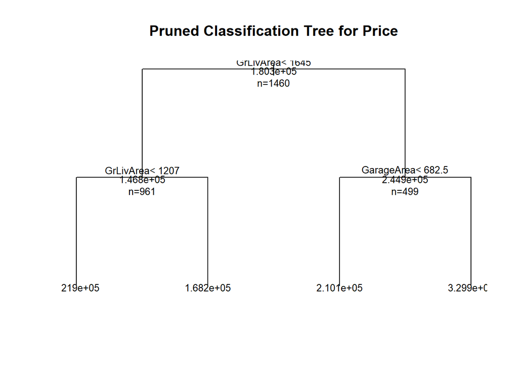

```r
set.seed(3014)
plot(pfit, uniform=TRUE,
     main="Pruned Classification Tree for Price")
text(pfit, use.n=TRUE, all=TRUE, cex=.8)
```

[figure not shown]

```r
fancyRpartPlot(pfit ,main="Pruned Classification Tree for Price",col="red")  #budanmis karar agacinin suslu seklidir
```

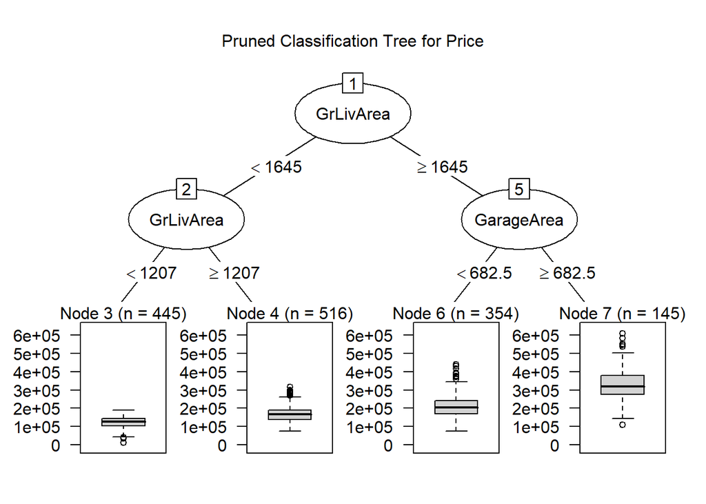

```r
party.pfit <- as.party(pfit)
plot(party.pfit ,main="Pruned Classification Tree for Price") #budanmis agacimizin farkli bir gosterimi
```

Semada gorulen budanmis karar agacimiz 4 yapraklidir.

```r
set.seed(3014)
data("data")
quantile(data$SalePrice, probs = seq(0, 1, by= 0.2))
```

```
##     0%    20%    40%    60%    80%   100%
##  12789 124000 146500 178536 230000 755000
```

```r
set.seed(3014)
table(traindata$SalePricecat)
```

```
##
##    0    1
## 1177  283
```

Tabloda ev fiyati 230000 den buyuk olanlar 1 ile ev fiyati 230000 den kucuk olanlar 0 ile gosterilmektedir.

#Bagging, Boosting, Random Forest

Tree komutu ile verimizdeki bagimli degisken (SalePricecat) e karsi iki bagimsiz degisken (GrLivArea,GarageArea) kullanarak agac tahmin ettik.

```r
set.seed(3014)
tree.data =tree(SalePricecat~ GrLivArea + GarageArea, data=traindata)
summary (tree.data)
```

```
##
## Classification tree:
## tree(formula = SalePricecat ~ GrLivArea + GarageArea, data = traindata)
## Number of terminal nodes:  7
## Residual mean deviance:  0.4603 = 668.9 / 1453
## Misclassification error rate: 0.09041 = 132 / 1460
```

Olusturdugumuz agac 7 yapraklidir.Residual Mean Deviance degeri ne kadar kucukse agac o kadar iyi tahmin yapar.Residual mean deviance degerimiz 0.4603 cikmistir.

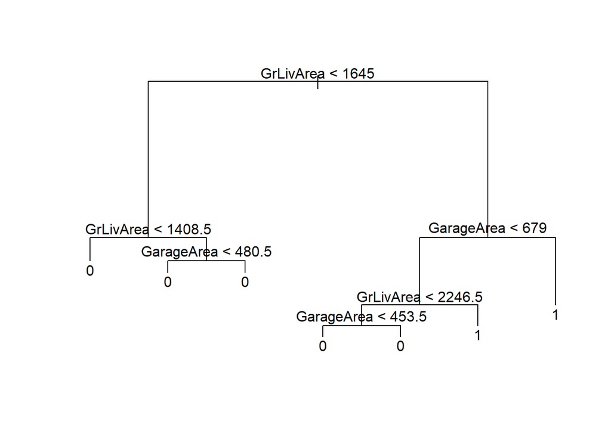

```r
set.seed(3014)
plot(tree.data)
text(tree.data ,pretty =0)
```

GrLivArea (Yukaridaki sinif (zemin) oturma alani metre kare ) degeri 1645’den buyukken ve GarageArea(Garajin metrekare cinsinden boyutu) degeri 679 dan buyukken ev fiyati yuksektir.

```r
set.seed(3014)
tree.data =tree(SalePricecat~ GrLivArea+GarageArea ,data=traindata )
tree.pred=predict(tree.data,testdata,type ="class")
table(tree.pred,testdata$SalePricecat)
```

```
##
## tree.pred    0    1
##         0 1124  135
##         1   50  161
```

```r
cat("\n","test seti icin agacin yanlis siniflandirma orani:", (135+50)/1470)
```

```
##
##  test seti icin agacin yanlis siniflandirma orani: 0.1258503
```

```r
cat("\n","test seti icin agacin dogru siniflandirma orani:", (1124+161)/1470)
```

```
##
##  test seti icin agacin dogru siniflandirma orani: 0.8741497
```

### Cross Validation ile Agacin budanmasi

```r
set.seed (3014)
cv.data =cv.tree(tree.data,FUN=prune.misclass) #cv.tree komutu ile agacin optimum
#karmasiklik duzeyi(yaprak sayisi) belirlenecektir.
#FUN=prune.misclass  komutu agacin karmasiklik duzeyinin  yanlis siniflandirma kriterine gore yapildigini soyler.
names(cv.data)
```

```
## [1] "size"   "dev"    "k"      "method"
```

```r
cv.data
```

```
## $size
## [1] 7 4 3 1
##
## $dev
## [1] 139 141 164 283
##
## $k
## [1] -Inf    0   27   62
##
## $method
## [1] "misclass"
##
## attr(,"class")
## [1] "prune"         "tree.sequence"
```

Yukarida cesitli agac boyutlarina gore deviationlar verilmistir. Metod olarak misclass i secerek minimum yaprak sayisini bulmak istiyoruz.

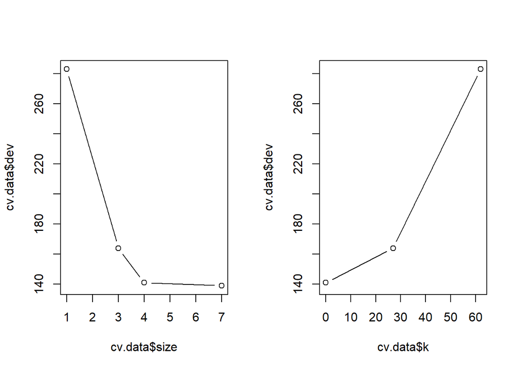

```r
set.seed(3014)
par(mfrow =c(1,2))
plot(cv.data$size ,cv.data$dev ,type="b")
plot(cv.data$k ,cv.data$dev ,type="b")
```

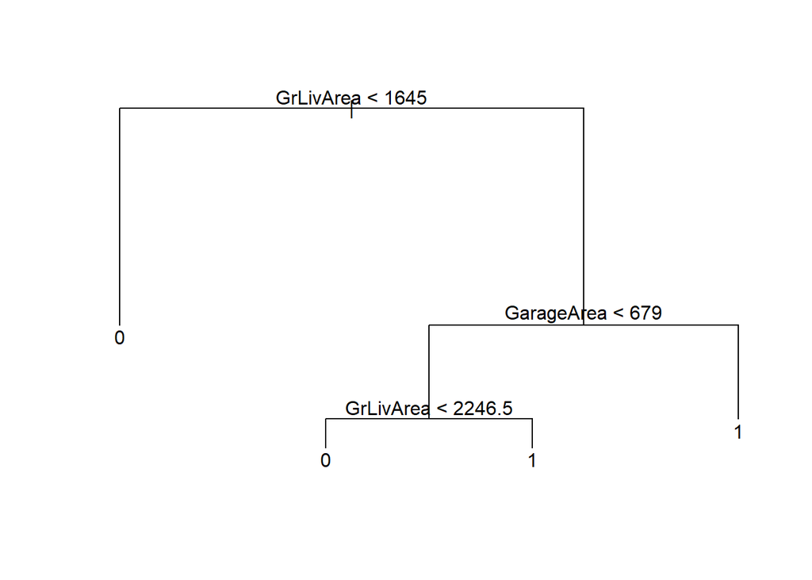

```r
set.seed(3014)
prune.data =prune.misclass(tree.data ,best =4)
plot(prune.data )
text(prune.data ,pretty =0)
```

```r
set.seed(3014)
tree.pred=predict(prune.data,testdata,type="class")

table(tree.pred,testdata$SalePricecat)
```

```
##
## tree.pred    0    1
##         0 1124  135
##         1   50  161
```

```r
#test seti icin agacin yanlis siniflandirma orani:
(135+50)/1470
```

```
## [1] 0.1258503
```

```r
#test seti icin agacin dogru siniflandirma orani:
(1124+161)/1470
```

```
## [1] 0.8741497
```

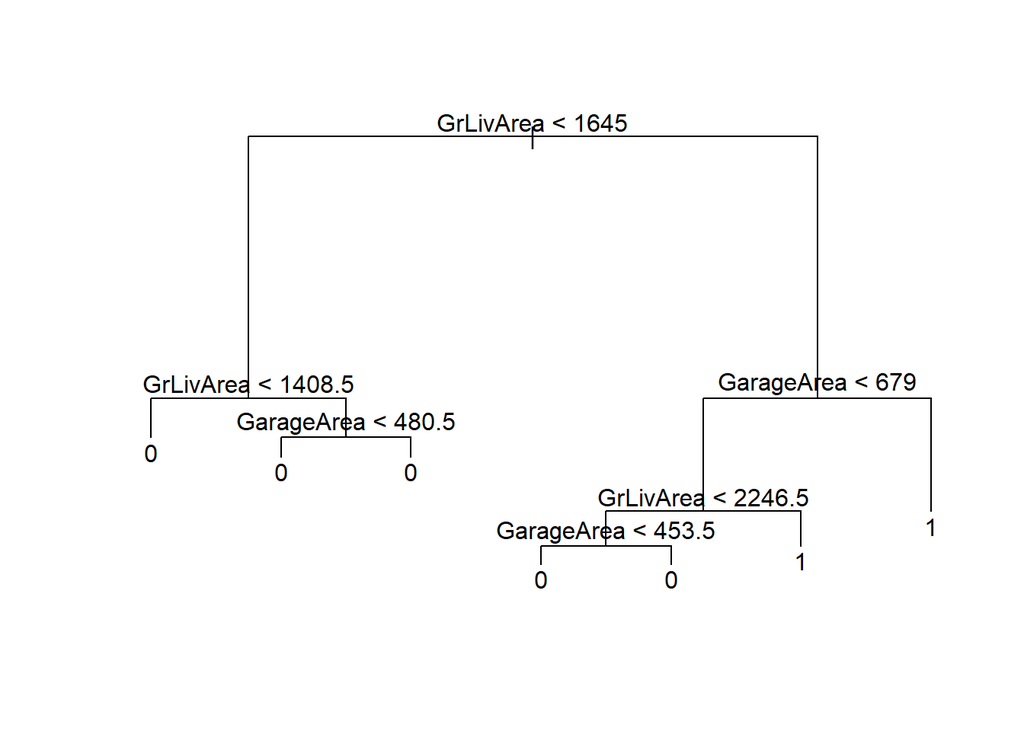

```r
set.seed(3014)
plot(tree.data )
text(tree.data ,pretty =0)
```

```r
set.seed(3014)
#tree.data =tree(SalePricecat~ GrLivArea+GarageArea ,data=traindata )
yhat=predict (tree.data,testdata)
mean((yhat-testdata$SalePrice)^2)
```

```
## [1] 39499719356
```

# Bagging(Torbalama), Random Forest(Karar Ormanı), Boosting(Yükseltme)

Yukaridaki kurdugumuz lmod regresyon modelimizdeki tum bagimsiz degiskenleri kullanarak Bagging yapalim. mtry : bagimsiz degisken sayisi.

```r
set.seed (3014)
bag.data =randomForest(SalePrice~OverallQual+
            YearRemodAdd+
             LotArea+
             OnestFlrSF+
             GrLivArea+
            GarageCars,data=traindata, mtry=6, importance=TRUE)
bag.data
```

```
##
## Call:
##  randomForest(formula = SalePrice ~ OverallQual + YearRemodAdd +      LotArea + OnestFlrSF + GrLivArea + GarageCars, data = traindata,      mtry = 6, importance = TRUE)
##                Type of random forest: regression
##                      Number of trees: 500
## No. of variables tried at each split: 6
##
##           Mean of squared residuals: 929838027
##                     % Var explained: 84.79
```

Mean of squared residuals = 929838027 cikmistir. % Var explained: 84.79 cikmistir.

Bagging modeli agac sayisini 500 alir ama buyuk verilerde bir sure sonra agac sayisi degisiklik yaratmaz.

```r
set.seed(3014)
yhat.bag = predict (bag.data , !is.na(testdata) )
mean(( yhat.bag -testdata$SalePrice)^2)
```

```
## [1] 24871914575
```

```r
sqrt(24871914575) #RMSE Degerimiz..
```

```
## [1] 157708.3
```

Bagging modelimizin hata kareler ortalamasi 24871914575 dir.RMSE 157708.3 cikmistir.

```r
set.seed(3014)
y =abs( traindata$SalePrice)
y.pred= predict (bag.data , !is.na(testdata) )

rmlse=(sqrt(1/length(y)*sum((log(y.pred +1)-log(traindata$SalePrice +1))^2)))
rmlse
```

```
## [1] 1.346003
```

Bagging modelimizin RMSLE si 1.346003 dir.

Agac sayimizi(ntree) azaltarak Bagging modelimize bakalim.

```r
set.seed(3014)
bag.data =randomForest(SalePrice~OverallQual+
             LotArea+
            YearRemodAdd+
             OnestFlrSF+
             GrLivArea+
            GarageCars,data=traindata, mtry=6, ntree =20)
yhat.bag = predict (bag.data , !is.na(testdata) )
mean((yhat.bag -testdata$SalePrice)^2)
```

```
## [1] 23706994165
```

Agac sayisini azalttigimizda da ortalamamiz 23706994165 cikti.

```r
sqrt(23706994165) #RMSE Degerimiz...
```

```
## [1] 153970.8
```

```r
set.seed(3014)
y =abs( traindata$SalePrice)
y.pred= predict (bag.data , !is.na(testdata) )

rmlse=(sqrt(1/length(y)*sum((log(y.pred +1)-log(traindata$SalePrice +1))^2)))
rmlse
```

```
## [1] 1.259837
```

RMSLE degerimiz 1.259837 cikmistir.

# Random Forest

```r
set.seed (3014)
rf.data =randomForest(SalePrice~OverallQual+
             LotArea+
            YearRemodAdd+
             OnestFlrSF+
             GrLivArea+
            GarageCars,data=traindata, mtry=500, importance =TRUE)
yhat.rf = predict (rf.data ,!is.na(testdata))
mean(( yhat.rf -testdata$SalePrice)^2)
```

```
## [1] 24662278271
```

```r
sqrt(24662278271) #RMSE Degerimiz..
```

```
## [1] 157042.3
```

```r
set.seed(3014)
y =abs( traindata$SalePrice)
y.pred=predict (rf.data ,!is.na(testdata))

rmlse=(sqrt(1/length(y)*sum((log(y.pred +1)-log(traindata$SalePrice +1))^2)))
rmlse
```

```
## [1] 1.330076
```

Random Forest yaptigimizda RMSLE degerimiz 1.330076 cikmistir.

```r
set.seed(3014)
library(randomForest)
importance (rf.data )
```

```
##                %IncMSE IncNodePurity
## OverallQual  113.39320  5.754996e+12
## LotArea       14.53557  4.504224e+11
## YearRemodAdd  28.14016  3.126365e+11
## OnestFlrSF    46.36322  7.218800e+11
## GrLivArea     72.77828  1.295414e+12
## GarageCars    26.34590  2.868326e+11
```

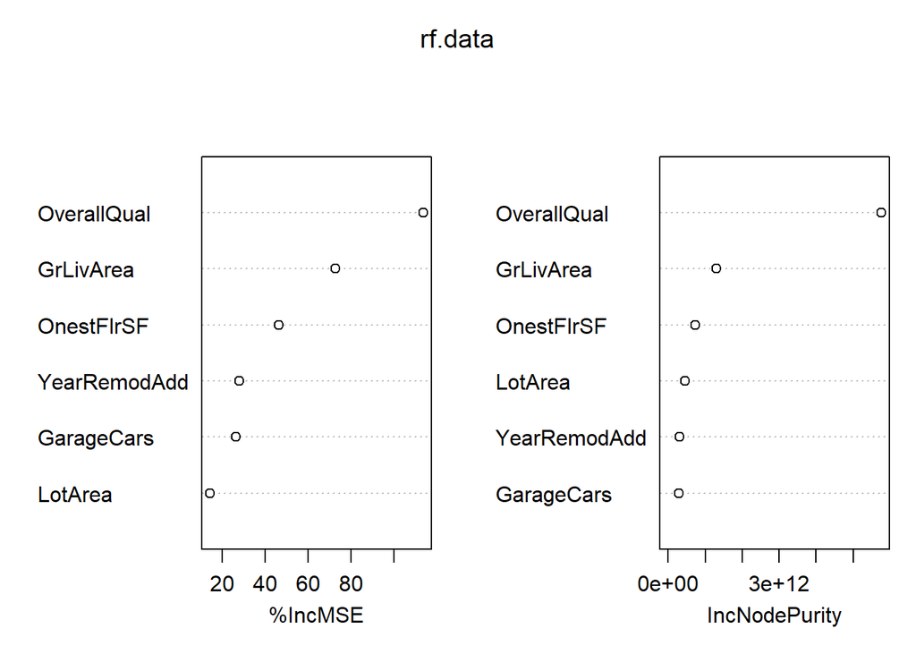

```r
varImpPlot (rf.data )
```

IncNodePurity grafigi bize safligi yani degiskenlerin onem sirasini gosterir. Ikı grafikte de goruldugu uzere bizim icin en anlamli iki degisken OverallQual ve GrLivArea dir.

#Boosting

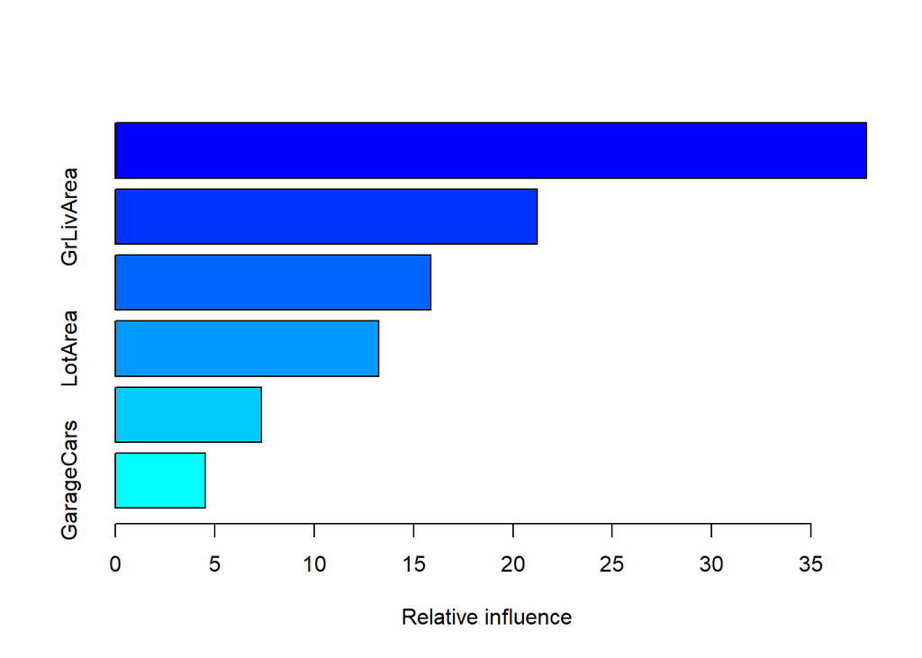

```
##                       var   rel.inf
## OverallQual   OverallQual 37.780422
## GrLivArea       GrLivArea 21.228504
## OnestFlrSF     OnestFlrSF 15.859520
## LotArea           LotArea 13.260543
## YearRemodAdd YearRemodAdd  7.359147
## GarageCars     GarageCars  4.511863
```

```r
library(gbm)
set.seed (3014)
boost.data =gbm(SalePrice~OverallQual+
             LotArea+
            YearRemodAdd+
             OnestFlrSF+
             GrLivArea+
            GarageCars,data=traindata, distribution="gaussian", n.trees =5000 , interaction.depth =5)
summary(boost.data)
```

Karar agaclari icin Boosting kullanildiginda da Summaryden de bakildigi uzere bu model icin en anlamli 2 degisken OverallQual ve GrLivArea dir.

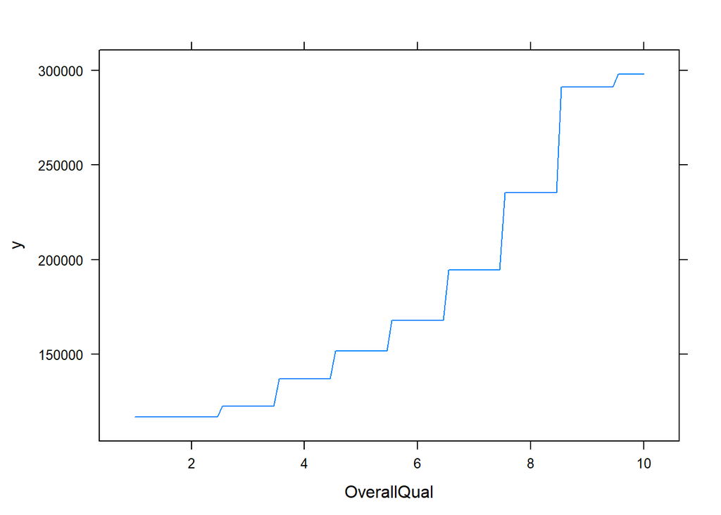

```r
par(mfrow =c(1,2))
plot(boost.data,i="OverallQual")
```

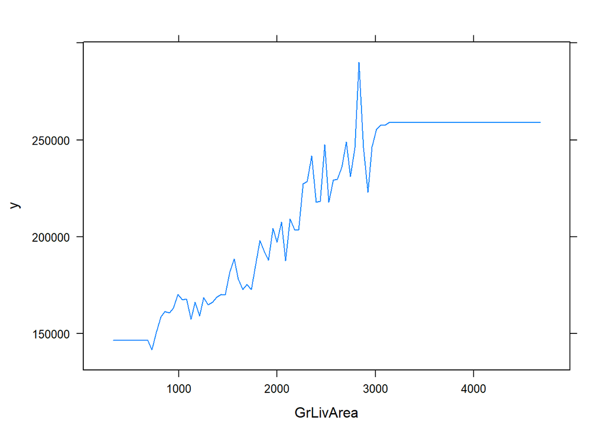

```r
plot(boost.data,i="GrLivArea")
```

Grafikte de goruldugu uzere OverallQual (Genel malzeme ve bitis kalitesi) arttikca ev fiyatimiz artmaktadir. Grafikte de goruldugu uzere GrLivArea(yukaridaki sinif (zemin) oturma alani metrekaresi) arttikca ev fiyatimiz artmaktadir.

```r
set.seed(3014)
yhat.boost=predict (boost.data ,testdata,n.trees =5000)
mean(( yhat.boost -testdata$SalePrice)^2)
```

```
## [1] 1188831166
```

Boosting yaptigimizda mean degerimiz 1188831166 cikmistir.

```r
sqrt(1188831166) #RMSE Degerimiz..
```

```
## [1] 34479.43
```

```r
set.seed(3014)
y =abs( traindata$SalePrice)
y.pred=predict (boost.data ,testdata,n.trees =5000)

rmlse=(sqrt(1/length(y)*sum((log(y.pred +1)-log(traindata$SalePrice +1))^2)))
rmlse
```

```
## [1] 0.5803201
```

```r
set.seed(3014)
boost.data =gbm(SalePrice~OverallQual+
             LotArea+
            YearRemodAdd+
             OnestFlrSF+
             GrLivArea+
            GarageCars,data=traindata, distribution=
"gaussian",n.trees =5000 , interaction.depth =4, shrinkage =0.2, #Shrinkage ogrenme hizi demektir(Manuel olarak girdik).Bu deger girilmediginde lambda ogrenme parametresi otomatik olarak verilir yukaridaki modellerdeki gibi.
verbose =F)
yhat.boost=predict (boost.data ,testdata,
n.trees =5000)
mean((yhat.boost -testdata$SalePrice)^2)
```

```
## [1] 1257180156
```

Boosting yaptigimizda mean degerimiz 1257180156 cikmistir.

```r
sqrt(1257180156) #RMSE Degerimiz..
```

```
## [1] 35456.74
```

```r
set.seed(3014)
y =abs( traindata$SalePrice)
y.pred=predict (boost.data ,testdata,
n.trees =5000)

rmlse=(sqrt(1/length(y)*sum((log(y.pred +1)-log(traindata$SalePrice +1))^2)))
rmlse
```

```
## [1] 0.5847732
```

Boosting yaptigimizda RMSLE degerimiz 0.5847732 cikmistir.

# XGBOOST

```r
data1<-dplyr::select(data,OverallQual,LotArea,YearRemodAdd,OnestFlrSF,GrLivArea,GarageCars,SalePrice)
data1
```

```
## # A tibble: 2,930 x 7
##    OverallQual LotArea YearRemodAdd OnestFlrSF GrLivArea GarageCars SalePrice
##          <int>   <int>        <int>      <int>     <int>      <int>     <int>
##  1           6   31770         1960       1656      1656          2    215000
##  2           5   11622         1961        896       896          1    105000
##  3           6   14267         1958       1329      1329          1    172000
##  4           7   11160         1968       2110      2110          2    244000
##  5           5   13830         1998        928      1629          2    189900
##  6           6    9978         1998        926      1604          2    195500
##  7           8    4920         2001       1338      1338          2    213500
##  8           8    5005         1992       1280      1280          2    191500
##  9           8    5389         1996       1616      1616          2    236500
## 10           7    7500         1999       1028      1804          2    189000
## # ... with 2,920 more rows
```

Xgboost icin kurdugumuz modeldeki degiskenlerimizi kullanarak yeni bir veri olusturduk.

```r
library(xgboost)

SalePrice = data1$SalePrice
label = as.integer(data1$SalePrice)-1
data1$SalePrice= NULL
```

```r
set.seed(3014)
n = nrow(data1)
train.index = sample(n,floor(0.498293515*n))
train.data = as.matrix(data1[train.index,])
train.label = label[train.index]
test.data = as.matrix(data1[-train.index,])
test.label = label[-train.index]
```

Yeni olusturdugumuz verimizi onceden belirledigimiz olceklerde test ve train olarak ayirdik.

```r
xgb.train = xgb.DMatrix(data=train.data,label=train.label)
xgb.test = xgb.DMatrix(data=test.data,label=test.label)
```

Verimiz icin xgb.train ve xgb.test matrislerini olusturduk. Lineer modelimiz icin Xgboost olusturdugumuzdan reg:linear komutunu kullandik.

```r
xgboost(data = xgb.train,
booster = "gbtree",
objective = "reg:linear",
max.depth = 5,
eta = 0.5,
nthread = 2,
nround = 2,
min_child_weight = 1,
subsample = 0.5,
colsample_bytree = 1,
num_parallel_tree = 1)
```

```
## ##### xgb.Booster
## raw: 3.4 Kb
## call:
##   xgb.train(params = params, data = dtrain, nrounds = nrounds,
##     watchlist = watchlist, verbose = verbose, print_every_n = print_every_n,
##     early_stopping_rounds = early_stopping_rounds, maximize = maximize,
##     save_period = save_period, save_name = save_name, xgb_model = xgb_model,
##     callbacks = callbacks, booster = "gbtree", objective = "reg:linear",
##     max.depth = 5, eta = 0.5, nthread = 2, min_child_weight = 1,
##     subsample = 0.5, colsample_bytree = 1, num_parallel_tree = 1)
## params (as set within xgb.train):
##   booster = "gbtree", objective = "reg:linear", max_depth = "5", eta = "0.5", nthread = "2", min_child_weight = "1", subsample = "0.5", colsample_bytree = "1", num_parallel_tree = "1", silent = "1"
## xgb.attributes:
##   niter
## callbacks:
##   cb.print.evaluation(period = print_every_n)
##   cb.evaluation.log()
## # of features: 6
## niter: 2
## nfeatures : 6
## evaluation_log:
##  iter train_rmse
##     1  103249.95
##     2   58933.98
```

1. ve 2. iterasyonumuz icin train_rmse degerlerine baktik, train_rmse degerimiz 2.iterasyonda daha kucuk cikmistir.

# Soru 2

## LOJISTIK REGRESYON MODELI

# DENGESIZ SINIFLANDIRMA

Lojistik regresyonda bagimli degiskenimiz kategorik olarak kullanilir.(SalePricecat)

```r
set.seed(3014)
model.lojistik=glm(SalePricecat~OverallQual+
             LotArea+
             YearRemodAdd+
             OnestFlrSF+
             GrLivArea+
             GarageCars ,family="binomial",data=traindata) #family kodu ile bagimli degiskenin dagilimi verilir
summary(model.lojistik)
```

```
##
## Call:
## glm(formula = SalePricecat ~ OverallQual + LotArea + YearRemodAdd +
##     OnestFlrSF + GrLivArea + GarageCars, family = "binomial",
##     data = traindata)
##
## Deviance Residuals:
##     Min       1Q   Median       3Q      Max
## -6.4702  -0.1786  -0.0339  -0.0045   3.2213
##
## Coefficients:
##                Estimate Std. Error z value Pr(>|z|)
## (Intercept)  -1.120e+02  2.312e+01  -4.844 1.27e-06 ***
## OverallQual   1.568e+00  1.746e-01   8.981  < 2e-16 ***
## LotArea       9.726e-05  2.263e-05   4.298 1.73e-05 ***
## YearRemodAdd  4.470e-02  1.158e-02   3.860 0.000114 ***
## OnestFlrSF    1.930e-03  3.947e-04   4.890 1.01e-06 ***
## GrLivArea     3.377e-03  3.748e-04   9.010  < 2e-16 ***
## GarageCars    5.769e-01  2.627e-01   2.196 0.028058 *
## ---
## Signif. codes:  0 '***' 0.001 '**' 0.01 '*' 0.05 '.' 0.1 ' ' 1
##
## (Dispersion parameter for binomial family taken to be 1)
##
##     Null deviance: 1435.87  on 1459  degrees of freedom
## Residual deviance:  442.88  on 1453  degrees of freedom
## AIC: 456.88
##
## Number of Fisher Scoring iterations: 8
```

Lojistik regresyonumuzu calistirdigimizda kullanilan bagimsiz degiskenlerimizin p valuelerinin 0.05 den kucuk oldugu gorulmekte yani bagimsiz degiskenlerimiz anlamlidir.Tahmin degerleri katsayilari pozitiftir. Ornegin OverallQual(Genel malzeme ve bitis kalitesi) arttikca ev fiyatida dogru orantili olarak artmaktadir.Lojistik modelimizi kurduktan sonra AIC degerimiz 456.88 cikmistir.Bu deger ne kadar kucukse o kadar iyidir.

Lojistik regresyon modellemek icin odds oranlari kullanilir.confint katsayilarin güven araliklarini olusturur.

```r
#odds oranlari
exp(cbind(OR = coef(model.lojistik), confint(model.lojistik)))
```

```
##                        OR        2.5 %       97.5 %
## (Intercept)  2.316817e-49 4.237939e-70 1.303973e-30
## OverallQual  4.797263e+00 3.450574e+00 6.851623e+00
## LotArea      1.000097e+00 1.000051e+00 1.000141e+00
## YearRemodAdd 1.045715e+00 1.023242e+00 1.070937e+00
## OnestFlrSF   1.001932e+00 1.001171e+00 1.002724e+00
## GrLivArea    1.003383e+00 1.002673e+00 1.004151e+00
## GarageCars   1.780588e+00 1.064006e+00 2.980398e+00
```

Olasilik degerlerini kesim noktalari icin kullanacagiz.

```r
olasilik=predict(model.lojistik,traindata,"response") #predict kotu model ciktisini verir
head(olasilik,10)
```

```
##            1            2            3            4            5            6
## 0.0667769634 0.0044823036 0.0085754150 0.6702159520 0.0002440930 0.0001336671
##            7            8            9           10
## 0.0028021934 0.0089321096 0.6435320877 0.0002424595
```

Bu ciktilar bize her bir eve ait fiyatin yuksek olup olmama olasiliklarini verir.

```r
traindata$sinif.tahmin=ifelse(olasilik>0.5,"1","0")
#Olasilik degerleri 0.5 den buyuk olan evlerin fiyatlari yuksek(yani1) , olasiligi 0.5 in altinda olan evlerin fiyatlarini dusuk(yani 0 ) olarak siniflandiriyoruz .

traindata$sinif.tahmin=as.factor(traindata$sinif.tahmin)
table.lojistik=table(Tahmin=traindata$sinif.tahmin, GercekDegerler=traindata$SalePricecat)
table.lojistik
```

```
##       GercekDegerler
## Tahmin    0    1
##      0 1146   50
##      1   31  233
```

Burada ise ozelliklerimizin fazla oldugu durumda ev fiyatinin da arttigi orani gormekteyiz. Evin fiyati dusukken tahminde de dusuk cikma degeri (True Negatif) 1146 dir. Evin fiyati dusukken tahminde yuksek cikmasi (False pozitif) 31 , Evin fiyati yuksekken tahminde dusuk cikmasi (False negatif) 50, Evin fiyati yuksekken tahminde yuksek cikmasi (True Pozitif ) 233 dir.

```r
accu.lojistik=(table.lojistik[1,1]+table.lojistik[2,2])/1460
accu.lojistik
```

```
## [1] 0.9445205
```

Dogru siniflandirma orani 0.9445205 dir.(ev fiyati gercekte pahaliyken tahminde de pahali cikmasi ve ev fiyati gercekte ucuzken tahminde de ucuz cikmasi).Modelin tum bulgularinin ozetlemek icin confusionMatrix fonksiyonu kullanalim

```r
#library(e1071) paketi ile calisir.
confusionMatrix(traindata$sinif.tahmin, traindata$SalePricecat,positive="1")
```

```
## Confusion Matrix and Statistics
##
##           Reference
## Prediction    0    1
##          0 1146   50
##          1   31  233
##
##                Accuracy : 0.9445
##                  95% CI : (0.9315, 0.9557)
##     No Information Rate : 0.8062
##     P-Value [Acc > NIR] : <2e-16
##
##                   Kappa : 0.8178
##
##  Mcnemar's Test P-Value : 0.0455
##
##             Sensitivity : 0.8233
##             Specificity : 0.9737
##          Pos Pred Value : 0.8826
##          Neg Pred Value : 0.9582
##              Prevalence : 0.1938
##          Detection Rate : 0.1596
##    Detection Prevalence : 0.1808
##       Balanced Accuracy : 0.8985
##
##        'Positive' Class : 1
##
```

Confusion Matrix sonucuna gore dogru siniflandirma orani Accuracy : 0.9445 dir. %95 guven araligimiz 0.9315, 0.9557 araligindadir.Kappa : 0.8178 cikmistir.Modelin iyiligini gostermek icin olcutler asagidaki gibidir.

Bu degerler ne kadar yuksekse model de o kadar iyi siniflandirma yapiyor demektir.Burada;

Sensitivity : 0.8233 true pozitif/ (true pozitif+false negatif) Specificity : 0.9737 true negatif/ (true negatif+false pozitif)  
Pos Pred Value : 0.8826  
Neg Pred Value : 0.9582  
Prevalence : 0.1938

Simdi kurulan lojistik regresyon modelimizden en anlamsiz degiskenimiz olan GarageCars modelden cikarilarak yeni bir model kuralim.

```r
set.seed(3014)
model.lojistik2=glm(SalePricecat~OverallQual+
             LotArea+
             YearRemodAdd+
             OnestFlrSF+
             GrLivArea
             ,family="binomial",data=traindata) #family kodu ile bagimli degiskenin dagilimi verilir
summary(model.lojistik2)
```

```
##
## Call:
## glm(formula = SalePricecat ~ OverallQual + LotArea + YearRemodAdd +
##     OnestFlrSF + GrLivArea, family = "binomial", data = traindata)
##
## Deviance Residuals:
##     Min       1Q   Median       3Q      Max
## -6.5750  -0.1746  -0.0353  -0.0048   3.2713
##
## Coefficients:
##                Estimate Std. Error z value Pr(>|z|)
## (Intercept)  -1.207e+02  2.289e+01  -5.273 1.34e-07 ***
## OverallQual   1.656e+00  1.711e-01   9.680  < 2e-16 ***
## LotArea       1.051e-04  2.255e-05   4.661 3.15e-06 ***
## YearRemodAdd  4.912e-02  1.145e-02   4.291 1.78e-05 ***
## OnestFlrSF    2.053e-03  3.897e-04   5.269 1.37e-07 ***
## GrLivArea     3.519e-03  3.692e-04   9.532  < 2e-16 ***
## ---
## Signif. codes:  0 '***' 0.001 '**' 0.01 '*' 0.05 '.' 0.1 ' ' 1
##
## (Dispersion parameter for binomial family taken to be 1)
##
##     Null deviance: 1435.9  on 1459  degrees of freedom
## Residual deviance:  447.7  on 1454  degrees of freedom
## AIC: 459.7
##
## Number of Fisher Scoring iterations: 8
```

Lojistik regresyonumuzu calistirdigimizda kullanilan bagimsiz degiskenlerimizin p valuelerinin 0.05 den kucuk oldugu gorulmekte yani bagimsiz degiskenlerimiz anlamlidir.Tahmin degerleri katsayilari pozitiftir. Ornegin OverallQual(Genel malzeme ve bitis kalitesi) arttikca ev fiyatida dogru orantili olarak artmaktadir.Lojistik modelimizi kurduktan sonra AIC degerimiz 459.7 cikmistir.Bu deger ne kadar kucukse o kadar iyidir.

Lojistik regresyon modellemek icin odds oranlari kullanilir.confint katsayilarin güven araliklarini olusturur.

```r
#odds oranlari
exp(cbind(OR = coef(model.lojistik2), confint(model.lojistik2)))
```

```
##                        OR        2.5 %       97.5 %
## (Intercept)  3.839809e-53 9.539061e-74 1.197439e-34
## OverallQual  5.236707e+00 3.795432e+00 7.431521e+00
## LotArea      1.000105e+00 1.000059e+00 1.000149e+00
## YearRemodAdd 1.050348e+00 1.028124e+00 1.075485e+00
## OnestFlrSF   1.002056e+00 1.001305e+00 1.002839e+00
## GrLivArea    1.003525e+00 1.002829e+00 1.004284e+00
```

olasilik degerlerini kesim noktalari icin kullanacagiz.

```r
olasilik2=predict(model.lojistik2,traindata,"response") #predict kotu model ciktisini verir
head(olasilik2,10)
```

```
##            1            2            3            4            5            6
## 0.0680723219 0.0037888502 0.0072757426 0.7010275334 0.0003401972 0.0001611314
##            7            8            9           10
## 0.0022044270 0.0074900243 0.6853819351 0.0003233974
```

Bu ciktilar bize her bir eve ait fiyatin yuksek olup olmama olasiliklarini verir.

```r
traindata$sinif.tahmin=ifelse(olasilik2>0.5,"1","0")
#Olasilik degerleri 0.5 den buyuk olan evlerin fiyatlari yuksek(yani1) , olasiligi 0.5 in altinda olan evlerin fiyatlarini dusuk(yani 0 ) olarak siniflandiriyoruz .

traindata$sinif.tahmin=as.factor(traindata$sinif.tahmin)
table.lojistik=table(Tahmin=traindata$sinif.tahmin, GercekDegerler=traindata$SalePricecat)
table.lojistik
```

```
##       GercekDegerler
## Tahmin    0    1
##      0 1146   53
##      1   31  230
```

Burada ise ozelliklerimizin fazla oldugu durumda ev fiyatinin da arttigi orani gormekteyiz.

Evin fiyati dusukken tahminde de dusuk cikma degeri (True Negatif) 1146 dir. Evin fiyati dusukken tahminde yuksek cikmasi (False pozitif) 31 , Evin fiyati yuksekken tahminde dusuk cikmasi (False negatif) 53. Evin fiyati yuksekken tahminde yuksek cikmasi (True Pozitif ) 230 dir.

Sensitivity : 0.8127 true pozitif/ (true pozitif+false negatif) Specificity : 0.9737 true negatif/ (true negatif+false pozitif)

```r
accu.lojistik=(table.lojistik[1,1]+table.lojistik[2,2])/1460
accu.lojistik
```

```
## [1] 0.9424658
```

Dogru siniflandirma orani 0.9424658 dir.(ev fiyati gercekte pahaliyken tahminde de pahali cikmasi ve ev fiyati gercekte ucuzken tahminde de ucuz cikmasi)

Modelin tum bulgularinin ozetlemek icin confusionMatrix fonksiyonu kullanalim

```r
#library(e1071) paketi ile calisir.
confusionMatrix(traindata$sinif.tahmin, traindata$SalePricecat,positive="1")
```

```
## Confusion Matrix and Statistics
##
##           Reference
## Prediction    0    1
##          0 1146   53
##          1   31  230
##
##                Accuracy : 0.9425
##                  95% CI : (0.9293, 0.9539)
##     No Information Rate : 0.8062
##     P-Value [Acc > NIR] : < 2e-16
##
##                   Kappa : 0.8103
##
##  Mcnemar's Test P-Value : 0.02195
##
##             Sensitivity : 0.8127
##             Specificity : 0.9737
##          Pos Pred Value : 0.8812
##          Neg Pred Value : 0.9558
##              Prevalence : 0.1938
##          Detection Rate : 0.1575
##    Detection Prevalence : 0.1788
##       Balanced Accuracy : 0.8932
##
##        'Positive' Class : 1
##
```

Confusion Matrix sonucuna gore dogru siniflandirma orani Accuracy : 0.9425 dir. %95 guven araligimiz 0.9293, 0.9539 araligindadir.Kappa : 0.8103 cikmistir.Modelin iyiligini gostermek icin olcutler asagidaki gibidir.

Bu degerler ne kadar yuksekse model de o kadar iyi siniflandirma yapiyor demektir.Burada;

Sensitivity : 0.8127 true pozitif/ (true pozitif+false negatif) Specificity : 0.9737 true negatif/ (true negatif+false pozitif)  
Pos Pred Value :0.8812  
Neg Pred Value : 0.9558  
Prevalence : 0.1938

Simdi kurulan lojistik regresyon modelimizden bir bagimsiz degisken daha cikaralim. YearRemodAdd bagimsiz degiskeni modelden cikarilarak yeni bir model kuralim.

```r
set.seed(3014)
model.lojistik3=glm(SalePricecat~OverallQual+
             LotArea+
             OnestFlrSF+
             GrLivArea
             ,family="binomial",data=traindata) #family kodu ile bagimli degiskenin dagilimi verilir
summary(model.lojistik3)
```

```
##
## Call:
## glm(formula = SalePricecat ~ OverallQual + LotArea + OnestFlrSF +
##     GrLivArea, family = "binomial", data = traindata)
##
## Deviance Residuals:
##     Min       1Q   Median       3Q      Max
## -6.4112  -0.2002  -0.0473  -0.0082   3.0253
##
## Coefficients:
##               Estimate Std. Error z value Pr(>|z|)
## (Intercept) -2.390e+01  1.584e+00 -15.093  < 2e-16 ***
## OverallQual  1.922e+00  1.595e-01  12.045  < 2e-16 ***
## LotArea      8.068e-05  2.112e-05   3.820 0.000134 ***
## OnestFlrSF   2.009e-03  3.850e-04   5.219  1.8e-07 ***
## GrLivArea    3.358e-03  3.490e-04   9.621  < 2e-16 ***
## ---
## Signif. codes:  0 '***' 0.001 '**' 0.01 '*' 0.05 '.' 0.1 ' ' 1
##
## (Dispersion parameter for binomial family taken to be 1)
##
##     Null deviance: 1435.87  on 1459  degrees of freedom
## Residual deviance:  470.41  on 1455  degrees of freedom
## AIC: 480.41
##
## Number of Fisher Scoring iterations: 8
```

Lojistik regresyonumuzu calistirdigimizda kullanilan bagimsiz degiskenlerimizin p valuelerinin 0.05 den kucuk oldugu gorulmekte yani bagimsiz degiskenlerimiz anlamlidir.Tahmin degerleri katsayilari pozitiftir. Ornegin OverallQual(Genel malzeme ve bitis kalitesi) arttikca ev fiyatida dogru orantili olarak artmaktadir.Lojistik modelimizi kurduktan sonra AIC degerimiz 480.41 cikmistir.Bu deger ne kadar kucukse o kadar iyidir.

Lojistik regresyon modellemek icin odds oranlari kullanilir. confint katsayilarin güven araliklarini olusturur.

```r
#odds oranlari
exp(cbind(OR = coef(model.lojistik3), confint(model.lojistik3)))
```

```
##                       OR        2.5 %       97.5 %
## (Intercept) 4.155693e-11 1.535924e-12 7.727674e-10
## OverallQual 6.832426e+00 5.073892e+00 9.494995e+00
## LotArea     1.000081e+00 1.000038e+00 1.000122e+00
## OnestFlrSF  1.002011e+00 1.001269e+00 1.002783e+00
## GrLivArea   1.003363e+00 1.002701e+00 1.004077e+00
```

Olasilik degerlerini kesim noktalari icin kullanacagiz.

```r
olasilik3=predict(model.lojistik3,traindata,"response") #predict kotu model ciktisini verir
head(olasilik3,10)
```

```
##            1            2            3            4            5            6
## 0.0475531268 0.0049313113 0.0354873054 0.5948077514 0.0001392142 0.0008815011
##            7            8            9           10
## 0.0068162987 0.0312616414 0.6510043466 0.0001554397
```

Bu ciktilar bize her bir eve ait fiyatin yuksek olup olmama olasiliklarini verir.

```r
traindata$sinif.tahmin=ifelse(olasilik3>0.5,"1","0")
#Olasilik degerleri 0.5 den buyuk olan evlerin fiyatlari yuksek(yani1) , olasiligi 0.5 in altinda olan evlerin fiyatlarini dusuk(yani 0 ) olarak siniflandiriyoruz .

traindata$sinif.tahmin=as.factor(traindata$sinif.tahmin)
table.lojistik=table(Tahmin=traindata$sinif.tahmin, GercekDegerler=traindata$SalePricecat)
table.lojistik
```

```
##       GercekDegerler
## Tahmin    0    1
##      0 1139   53
##      1   38  230
```

Burada ise ozelliklerimizin fazla oldugu durumda ev fiyatinin da arttigi orani gormekteyiz.

Evin fiyati dusukken tahminde de dusuk cikma degeri (True Negatif) 1139 dir. Evin fiyati dusukken tahminde yuksek cikmasi (False pozitif) 38 , Evin fiyati yuksekken tahminde dusuk cikmasi (False negatif) 53. Evin fiyati yuksekken tahminde yuksek cikmasi (True Pozitif ) 230 dir.

Sensitivity : 0.8127 true pozitif/ (true pozitif+false negatif) Specificity : 0.9677 true negatif/ (true negatif+false pozitif)

```r
accu.lojistik=(table.lojistik[1,1]+table.lojistik[2,2])/1460
accu.lojistik
```

```
## [1] 0.9376712
```

Dogru siniflandirma orani 0.9376712 dir.(ev fiyati gercekte pahaliyken tahminde de pahali cikmasi ve ev fiyati gercekte ucuzken tahminde de ucuz cikmasi)

Modelin tum bulgularinin ozetlemek icin confusionMatrix fonksiyonu kullanalim

```r
#library(e1071) paketi ile calisir.
confusionMatrix(traindata$sinif.tahmin, traindata$SalePricecat,positive="1")
```

```
## Confusion Matrix and Statistics
##
##           Reference
## Prediction    0    1
##          0 1139   53
##          1   38  230
##
##                Accuracy : 0.9377
##                  95% CI : (0.924, 0.9495)
##     No Information Rate : 0.8062
##     P-Value [Acc > NIR] : <2e-16
##
##                   Kappa : 0.7965
##
##  Mcnemar's Test P-Value : 0.1422
##
##             Sensitivity : 0.8127
##             Specificity : 0.9677
##          Pos Pred Value : 0.8582
##          Neg Pred Value : 0.9555
##              Prevalence : 0.1938
##          Detection Rate : 0.1575
##    Detection Prevalence : 0.1836
##       Balanced Accuracy : 0.8902
##
##        'Positive' Class : 1
##
```

Confusion Matrix sonucuna gore dogru siniflandirma orani Accuracy : 0.9377 dir. %95 guven araligimiz 0.924, 0.9495 araligindadir.Kappa : 0.7965 cikmistir.Modelin iyiligini gostermek icin olcutler asagidaki gibidir. Bu degerler ne kadar yuksekse model de o kadar iyi siniflandirma yapiyor demektir.Burada; Sensitivity : 0.8127 true pozitif/ (true pozitif+false negatif) Specificity : 0.9677 true negatif/ (true negatif+false pozitif)  
Pos Pred Value :0.8582  
Neg Pred Value : 0.9555  
Prevalence : 0.1938

Kurulan lojistik regresyon modelleri sonuclarina baktigimizda ;

model.lojistik = Accuracy : 0.9445 , Sensitivity : 0.8233 , Specificity : 0.9737 , AIC: 456.88,Kappa : 0.8178

model.lojistik2 = Accuracy : 0.9425 , Sensitivity : 0.8127 , Specificity : 0.9737 , AIC: 459.7,Kappa : 0.8103

model.lojistik3 = Accuracy : 0.9377, Sensitivity : 0.8127 , Specificity : 0.9677 , AIC: 480.41 ,Kappa : 0.7965

Modeli en iyi aciklayan ve sensitivity si en yuksek olan model.lojistiktir. Yani ilk kurulan modelden (OverallQual+ LotArea+ YearRemodAdd+ OnestFlrSF+ GrLivArea+ GarageCars) hic bir bagimsiz degiskenimizi cikarmadan devam edecegiz.

### Modelin tahmin gucunun degerlendirilmesi

Evin fiyatinin olasiligini tahmin edelim

```r
traindata$probabilities <- predict(model.lojistik, type = "response")
head(traindata$probabilities,5)
```

```
##           1           2           3           4           5
## 0.066776963 0.004482304 0.008575415 0.670215952 0.000244093
```

Kesim noktasi(esik degeri) degerini yukaridaki model icin 0.5 almistik simdi 0.1 olacak sekilde degistiriyoruz.

```r
traindata$sinif.tahmin<- ifelse(traindata$probabilities > 0.1, "1", "0")
traindata$sinif.tahmin=as.factor(traindata$sinif.tahmin)
```

Tahmin ve gercek degerleri karsilastirmak icin asagidaki tabloya(hata matrisi) bakilabilir.

```r
table(Tahmin=traindata$sinif.tahmin, Referans=traindata$SalePricecat)
```

```
##       Referans
## Tahmin    0    1
##      0 1003   10
##      1  174  273
```

Modelin tum bulgularinin ozetlemek icin confusionMatrix fonksiyonu kullanilabilir.

```r
library(e1071)
confusionMatrix(traindata$sinif.tahmin, traindata$SalePricecat ,positive="1")
```

```
## Confusion Matrix and Statistics
##
##           Reference
## Prediction    0    1
##          0 1003   10
##          1  174  273
##
##                Accuracy : 0.874
##                  95% CI : (0.8559, 0.8906)
##     No Information Rate : 0.8062
##     P-Value [Acc > NIR] : 3.439e-12
##
##                   Kappa : 0.6695
##
##  Mcnemar's Test P-Value : < 2.2e-16
##
##             Sensitivity : 0.9647
##             Specificity : 0.8522
##          Pos Pred Value : 0.6107
##          Neg Pred Value : 0.9901
##              Prevalence : 0.1938
##          Detection Rate : 0.1870
##    Detection Prevalence : 0.3062
##       Balanced Accuracy : 0.9084
##
##        'Positive' Class : 1
##
```

Sonucumuza gore modelimizin Accuracy : 0.874 cikmistir ve Sensitivity : 0.9647 olmus ve artmistir.Asil istegimiz sensitivity nin artmasidir.Kappa : 0.6695 ,kesim noktasi 0.08 alinabilir

```r
traindata$sinif.tahmin<- ifelse(traindata$probabilities > 0.08, "1", "0")
traindata$sinif.tahmin=as.factor(traindata$sinif.tahmin)
confusionMatrix(traindata$sinif.tahmin, traindata$SalePricecat,positive="1")
```

```
## Confusion Matrix and Statistics
##
##           Reference
## Prediction   0   1
##          0 977   9
##          1 200 274
##
##                Accuracy : 0.8568
##                  95% CI : (0.8378, 0.8744)
##     No Information Rate : 0.8062
##     P-Value [Acc > NIR] : 2.305e-07
##
##                   Kappa : 0.6354
##
##  Mcnemar's Test P-Value : < 2.2e-16
##
##             Sensitivity : 0.9682
##             Specificity : 0.8301
##          Pos Pred Value : 0.5781
##          Neg Pred Value : 0.9909
##              Prevalence : 0.1938
##          Detection Rate : 0.1877
##    Detection Prevalence : 0.3247
##       Balanced Accuracy : 0.8991
##
##        'Positive' Class : 1
##
```

Modelimizin kesim noktasini dusurdukce sensitivity artmaktadir. Bu sebeple kesim noktasi icin 0.08 kullanilacaktir. Accuracy : 0.8568 ,Kappa : 0.6354 , Sensitivity : 0.9682 , Specificity : 0.8301

Sensitivity en yuksek cikan model icin simdi karar agaclarina gecelim ;

```r
set.seed(3014)
model.lojistik=glm(SalePricecat~OverallQual+
             LotArea+
             YearRemodAdd+
             OnestFlrSF+
             GrLivArea+
             GarageCars ,family="binomial",data=traindata) #family kodu ile bagimli degiskenin dagilimi verilir
summary(model.lojistik)
```

```
##
## Call:
## glm(formula = SalePricecat ~ OverallQual + LotArea + YearRemodAdd +
##     OnestFlrSF + GrLivArea + GarageCars, family = "binomial",
##     data = traindata)
##
## Deviance Residuals:
##     Min       1Q   Median       3Q      Max
## -6.4702  -0.1786  -0.0339  -0.0045   3.2213
##
## Coefficients:
##                Estimate Std. Error z value Pr(>|z|)
## (Intercept)  -1.120e+02  2.312e+01  -4.844 1.27e-06 ***
## OverallQual   1.568e+00  1.746e-01   8.981  < 2e-16 ***
## LotArea       9.726e-05  2.263e-05   4.298 1.73e-05 ***
## YearRemodAdd  4.470e-02  1.158e-02   3.860 0.000114 ***
## OnestFlrSF    1.930e-03  3.947e-04   4.890 1.01e-06 ***
## GrLivArea     3.377e-03  3.748e-04   9.010  < 2e-16 ***
## GarageCars    5.769e-01  2.627e-01   2.196 0.028058 *
## ---
## Signif. codes:  0 '***' 0.001 '**' 0.01 '*' 0.05 '.' 0.1 ' ' 1
##
## (Dispersion parameter for binomial family taken to be 1)
##
##     Null deviance: 1435.87  on 1459  degrees of freedom
## Residual deviance:  442.88  on 1453  degrees of freedom
## AIC: 456.88
##
## Number of Fisher Scoring iterations: 8
```

Lojistik regresyonumuzu calistirdigimizda kullanilan bagimsiz degiskenlerimizin p valuelerinin 0.05 den kucuk oldugu gorulmekte yani bagimsiz degiskenlerimiz anlamlidir.Tahmin degerleri katsayilari pozitiftir. Ornegin OverallQual(Genel malzeme ve bitis kalitesi) arttikca ev fiyatida dogru orantili olarak artmaktadir.Lojistik modelimizi kurduktan sonra AIC degerimiz 456.88 cikmistir.Bu deger ne kadar kucukse o kadar iyidir.

Lojistik regresyon modellemek icin odds oranlari kullanilir.confint katsayilarin güven araliklarini olusturur.

```r
#odds oranlari
exp(cbind(OR = coef(model.lojistik), confint(model.lojistik)))
```

```
##                        OR        2.5 %       97.5 %
## (Intercept)  2.316817e-49 4.237939e-70 1.303973e-30
## OverallQual  4.797263e+00 3.450574e+00 6.851623e+00
## LotArea      1.000097e+00 1.000051e+00 1.000141e+00
## YearRemodAdd 1.045715e+00 1.023242e+00 1.070937e+00
## OnestFlrSF   1.001932e+00 1.001171e+00 1.002724e+00
## GrLivArea    1.003383e+00 1.002673e+00 1.004151e+00
## GarageCars   1.780588e+00 1.064006e+00 2.980398e+00
```

olasilik degerlerini kesim noktalari icin kullanacagiz.

```r
olasilik=predict(model.lojistik,traindata,"response") #predict kotu model ciktisini verir
head(olasilik,10)
```

```
##            1            2            3            4            5            6
## 0.0667769634 0.0044823036 0.0085754150 0.6702159520 0.0002440930 0.0001336671
##            7            8            9           10
## 0.0028021934 0.0089321096 0.6435320877 0.0002424595
```

Bu ciktilar bize her bir eve ait fiyatin yuksek olup olmama olasiliklarini verir.

```r
traindata$sinif.tahmin=ifelse(olasilik>0.5,"1","0")
#Olasilik degerleri 0.5 den buyuk olan evlerin fiyatlari yuksek(yani1) , olasiligi 0.5 in altinda olan evlerin fiyatlarini dusuk(yani 0 ) olarak siniflandiriyoruz .

traindata$sinif.tahmin=as.factor(traindata$sinif.tahmin)
table.lojistik=table(Tahmin=traindata$sinif.tahmin, GercekDegerler=traindata$SalePricecat)
table.lojistik
```

```
##       GercekDegerler
## Tahmin    0    1
##      0 1146   50
##      1   31  233
```

Burada ise ozelliklerimizin fazla oldugu durumda ev fiyatinin da arttigi orani gormekteyiz. Evin fiyati dusukken tahminde de dusuk cikma degeri (True Negatif) 1146 dir. Evin fiyati dusukken tahminde yuksek cikmasi (False pozitif) 31 , Evin fiyati yuksekken tahminde dusuk cikmasi (False negatif) 50, Evin fiyati yuksekken tahminde yuksek cikmasi (True Pozitif ) 233 dir.

# F1 Skoru

$$F_1=\left(\frac{recall^{-1}+precision^{-1}}{2}\right)^{-1}=2 \times \frac{precision \times recall}{precision+recall}$$

Precision = TP/TP+FP

```r
Precision=233/233+31
Precision
```

```
## [1] 32
```

Recall = TP/TP+FN

```r
Recal=233/233+50
Recal
```

```
## [1] 51
```

F1 Score = 2* (Recall * Precision) / (Recall + Precision)

```r
F1= 2*(51*32)/(51+32)
F1
```

```
## [1] 39.3253
```

```r
accu.lojistik=(table.lojistik[1,1]+table.lojistik[2,2])/1460
accu.lojistik
```

```
## [1] 0.9445205
```

Dogru siniflandirma orani 0.9445205 dir.(ev fiyati gercekte pahaliyken tahminde de pahali cikmasi ve ev fiyati gercekte ucuzken tahminde de ucuz cikmasi)

Modelin tum bulgularinin ozetlemek icin confusionMatrix fonksiyonu kullanalim

```r
#library(e1071) paketi ile calisir.
confusionMatrix(traindata$sinif.tahmin, traindata$SalePricecat,positive="1")
```

```
## Confusion Matrix and Statistics
##
##           Reference
## Prediction    0    1
##          0 1146   50
##          1   31  233
##
##                Accuracy : 0.9445
##                  95% CI : (0.9315, 0.9557)
##     No Information Rate : 0.8062
##     P-Value [Acc > NIR] : <2e-16
##
##                   Kappa : 0.8178
##
##  Mcnemar's Test P-Value : 0.0455
##
##             Sensitivity : 0.8233
##             Specificity : 0.9737
##          Pos Pred Value : 0.8826
##          Neg Pred Value : 0.9582
##              Prevalence : 0.1938
##          Detection Rate : 0.1596
##    Detection Prevalence : 0.1808
##       Balanced Accuracy : 0.8985
##
##        'Positive' Class : 1
##
```

Confusion Matrix sonucuna gore dogru siniflandirma orani Accuracy : 0.9445 dir. %95 guven araligimiz 0.9315, 0.9557 araligindadir.Kappa : 0.8178 cikmistir.

Modelin iyiligini gostermek icin olcutler asagidaki gibidir.

Bu degerler ne kadar yuksekse model de o kadar iyi siniflandirma yapiyor demektir.Burada;

Sensitivity : 0.8233 true pozitif/ (true pozitif+false negatif) Specificity : 0.9737 true negatif/ (true negatif+false pozitif)  
Pos Pred Value : 0.8826  
Neg Pred Value : 0.9582  
Prevalence : 0.1938

```r
set.seed(3014)
fit4=rpart(SalePricecat~OverallQual+
             LotArea+
             YearRemodAdd+
             OnestFlrSF+
             GrLivArea+
             GarageCars, data = traindata) #gini index
summary(fit4)
```

```
## Call:
## rpart(formula = SalePricecat ~ OverallQual + LotArea + YearRemodAdd +
##     OnestFlrSF + GrLivArea + GarageCars, data = traindata)
##   n= 1460
##
##           CP nsplit rel error    xerror       xstd
## 1 0.51590106      0 1.0000000 1.0000000 0.05337263
## 2 0.05300353      1 0.4840989 0.4840989 0.03937108
## 3 0.04416961      2 0.4310954 0.5088339 0.04025746
## 4 0.02120141      4 0.3427562 0.4452297 0.03791406
## 5 0.01766784      5 0.3215548 0.4240283 0.03708345
## 6 0.01000000      6 0.3038869 0.4204947 0.03694239
##
## Variable importance
##  OverallQual    GrLivArea   GarageCars   OnestFlrSF YearRemodAdd      LotArea
##           49           16           16            9            5            5
##
## Node number 1: 1460 observations,    complexity param=0.5159011
##   predicted class=0  expected loss=0.1938356  P(node) =1
##     class counts:  1177   283
##    probabilities: 0.806 0.194
##   left son=2 (1224 obs) right son=3 (236 obs)
##   Primary splits:
##       OverallQual  < 7.5     to the left,  improve=213.28010, (0 missing)
##       GarageCars   < 2.5     to the left,  improve=158.02350, (0 missing)
##       GrLivArea    < 1785    to the left,  improve=133.08580, (0 missing)
##       OnestFlrSF   < 1443    to the left,  improve=111.98930, (0 missing)
##       YearRemodAdd < 1985.5  to the left,  improve= 66.83336, (0 missing)
##   Surrogate splits:
##       GarageCars   < 2.5     to the left,  agree=0.892, adj=0.331, (0 split)
##       OnestFlrSF   < 1688.5  to the left,  agree=0.863, adj=0.153, (0 split)
##       GrLivArea    < 2329    to the left,  agree=0.853, adj=0.089, (0 split)
##       YearRemodAdd < 2007.5  to the left,  agree=0.849, adj=0.064, (0 split)
##
## Node number 2: 1224 observations,    complexity param=0.04416961
##   predicted class=0  expected loss=0.0751634  P(node) =0.8383562
##     class counts:  1132    92
##    probabilities: 0.925 0.075
##   left son=4 (1149 obs) right son=5 (75 obs)
##   Primary splits:
```

[output cut: 81 more lines]

```
##
## Node number 13: 7 observations
##   predicted class=1  expected loss=0.1428571  P(node) =0.004794521
##     class counts:     1     6
##    probabilities: 0.143 0.857
##
## Node number 22: 10 observations
##   predicted class=0  expected loss=0.2  P(node) =0.006849315
##     class counts:     8     2
##    probabilities: 0.800 0.200
##
## Node number 23: 49 observations
##   predicted class=1  expected loss=0.1836735  P(node) =0.03356164
##     class counts:     9    40
##    probabilities: 0.184 0.816
```

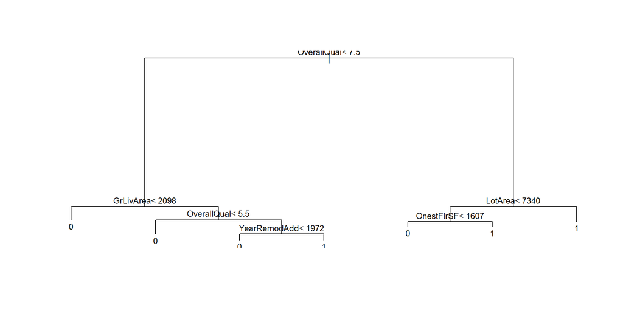

Karar agacimiz 7 yapraklidir.

```r
set.seed(3014)
treefit4 <- tree(SalePricecat~OverallQual+
             LotArea+
             YearRemodAdd+
             OnestFlrSF+
             GrLivArea+
             GarageCars, data = traindata,
mindev = 0.001)
summary(treefit4)
```

```
##
## Classification tree:
## tree(formula = SalePricecat ~ OverallQual + LotArea + YearRemodAdd +
##     OnestFlrSF + GrLivArea + GarageCars, data = traindata, mindev = 0.001)
## Variables actually used in tree construction:
## [1] "OverallQual"  "GrLivArea"    "OnestFlrSF"   "LotArea"      "YearRemodAdd"
## Number of terminal nodes:  56
## Residual mean deviance:  0.1623 = 227.8 / 1404
## Misclassification error rate: 0.0411 = 60 / 1460
```

mindev = 0.001 alindiginda yaprak sayimiz artmistir. Daha kompleks bir hale donusmustur.Residual mean deviance: 0.1623 cikmistir. mindev: tuning parameters

# CART model building

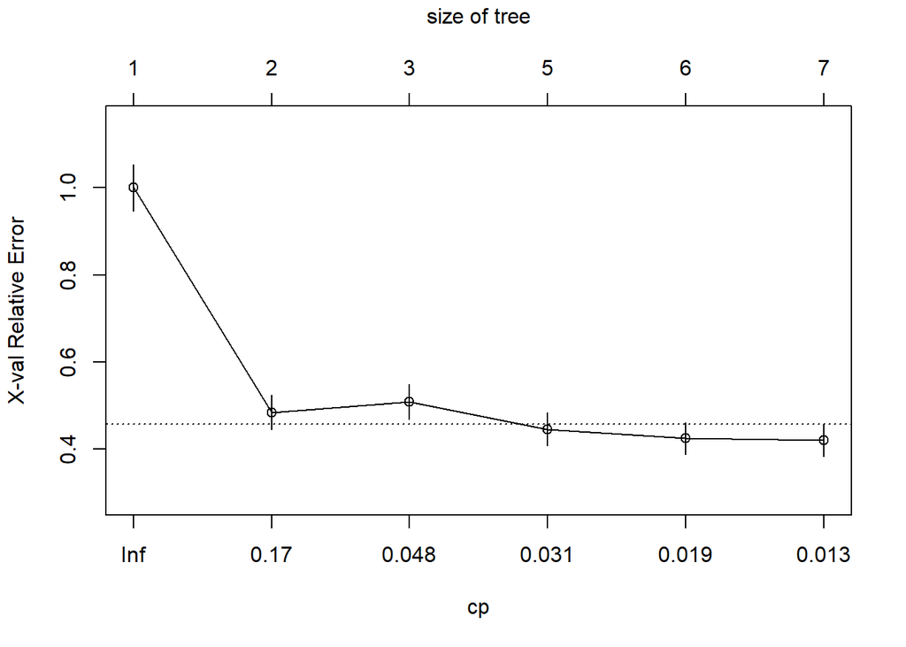

```r
set.seed(3014)
fit5 <- rpart(SalePricecat~OverallQual+
             LotArea+
             YearRemodAdd+
             OnestFlrSF+
             GrLivArea+
             GarageCars,data=traindata)
plotcp(fit5) # capraz dogrulama sonuclarini gorsellestirir
```

Burada en dusuk complex parametere degeri secilir. Burada 0.013 cikmistir.

# Agacin gorsellestirilmesi

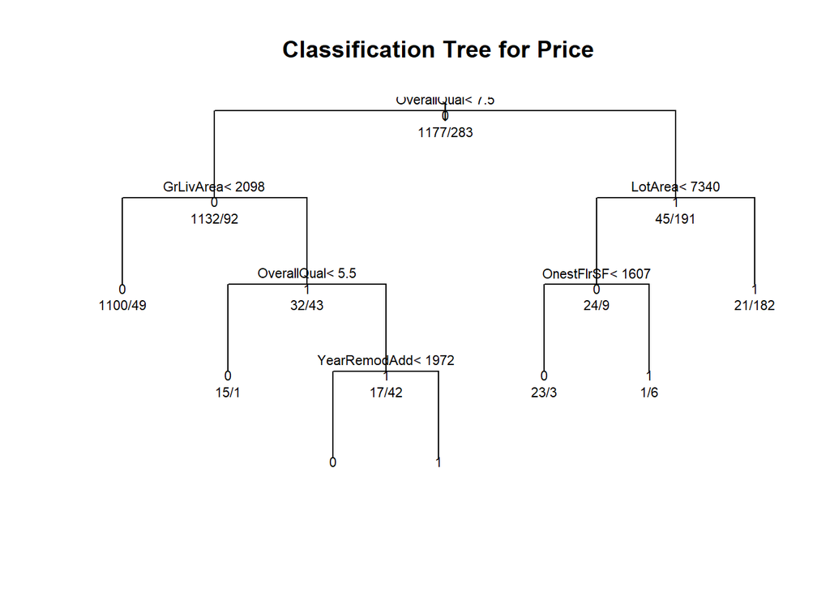

```r
plot(fit5, uniform=TRUE,
     main="Classification Tree for Price")
text(fit5, use.n=TRUE, all=TRUE, cex=0.7)
```

[figure not shown]

```r
fancyRpartPlot(fit5,main="Classification Tree for Price",col="red")  #budanmamis karar agacinin suslu halidir
```

Yaprak uclarinda her birinde ki gozlem sayilarini gosterir.(n)Bu agac cok over fit etmis oluyor yorumlanmasi cok zordur ve test veri seti icin iyi bir model vermez.Budanmis agacimiza bakalim;

# Karar agacinin budanmasi

```r
pfit<- prune(fit5, cp=fit5$cptable[which.min(fit5$cptable[,"xerror"]),"CP"])

# Bu kod, belirtilen cp degerine gore kurulacaktir.
pfit<- prune(fit5, cp=0.05)

summary(pfit)
```

```
## Call:
## rpart(formula = SalePricecat ~ OverallQual + LotArea + YearRemodAdd +
##     OnestFlrSF + GrLivArea + GarageCars, data = traindata)
##   n= 1460
##
##           CP nsplit rel error    xerror       xstd
## 1 0.51590106      0 1.0000000 1.0000000 0.05337263
## 2 0.05300353      1 0.4840989 0.4840989 0.03937108
## 3 0.05000000      2 0.4310954 0.5088339 0.04025746
##
## Variable importance
##  OverallQual   GarageCars   OnestFlrSF    GrLivArea      LotArea YearRemodAdd
##           56           19            9            7            6            4
##
## Node number 1: 1460 observations,    complexity param=0.5159011
##   predicted class=0  expected loss=0.1938356  P(node) =1
##     class counts:  1177   283
##    probabilities: 0.806 0.194
##   left son=2 (1224 obs) right son=3 (236 obs)
##   Primary splits:
##       OverallQual  < 7.5    to the left,  improve=213.28010, (0 missing)
##       GarageCars   < 2.5    to the left,  improve=158.02350, (0 missing)
##       GrLivArea    < 1785   to the left,  improve=133.08580, (0 missing)
##       OnestFlrSF   < 1443   to the left,  improve=111.98930, (0 missing)
##       YearRemodAdd < 1985.5 to the left,  improve= 66.83336, (0 missing)
##   Surrogate splits:
##       GarageCars   < 2.5    to the left,  agree=0.892, adj=0.331, (0 split)
##       OnestFlrSF   < 1688.5 to the left,  agree=0.863, adj=0.153, (0 split)
##       GrLivArea    < 2329   to the left,  agree=0.853, adj=0.089, (0 split)
##       YearRemodAdd < 2007.5 to the left,  agree=0.849, adj=0.064, (0 split)
##
## Node number 2: 1224 observations
##   predicted class=0  expected loss=0.0751634  P(node) =0.8383562
##     class counts:  1132    92
##    probabilities: 0.925 0.075
##
## Node number 3: 236 observations,    complexity param=0.05300353
##   predicted class=1  expected loss=0.190678  P(node) =0.1616438
##     class counts:    45   191
##    probabilities: 0.191 0.809
##   left son=6 (33 obs) right son=7 (203 obs)
##   Primary splits:
##       LotArea      < 7340   to the left,  improve=22.092900, (0 missing)
##       GrLivArea    < 1616   to the left,  improve=21.942750, (0 missing)
##       GarageCars   < 2.5    to the left,  improve=13.491130, (0 missing)
##       OnestFlrSF   < 1599.5 to the left,  improve=10.568150, (0 missing)
##       YearRemodAdd < 1992.5 to the left,  improve= 9.638473, (0 missing)
##   Surrogate splits:
##       GrLivArea < 1394.5 to the left,  agree=0.911, adj=0.364, (0 split)
##
## Node number 6: 33 observations
##   predicted class=0  expected loss=0.2727273  P(node) =0.02260274
##     class counts:    24     9
##    probabilities: 0.727 0.273
##
## Node number 7: 203 observations
##   predicted class=1  expected loss=0.1034483  P(node) =0.1390411
##     class counts:    21   182
##    probabilities: 0.103 0.897
```

cp degeri kuculdukce daha kompleks agaclar verir. Bu sebeple cp degerini hesaplayarak 0.05 alarak kompleksligi azalttik bulduk.

# Budanmis agacin cizilmesi

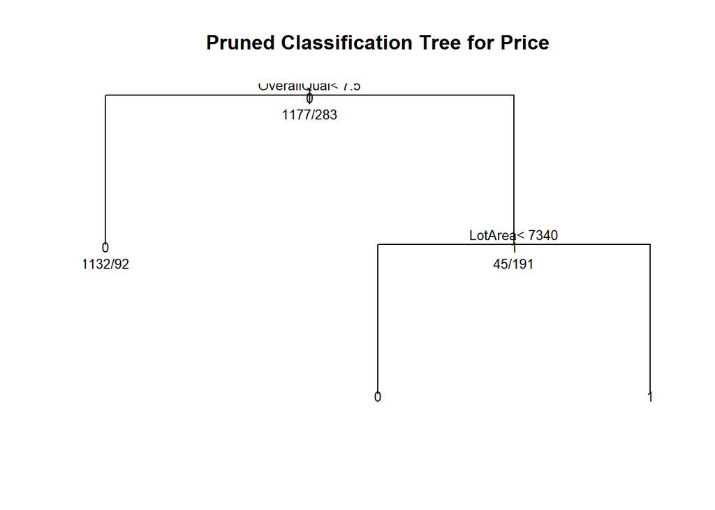

```r
plot(pfit, uniform=TRUE,
     main="Pruned Classification Tree for Price")
text(pfit, use.n=TRUE, all=TRUE, cex=.8)
```

[figure not shown]

```r
fancyRpartPlot(pfit ,main="Pruned Classification Tree for Price",col="red")  #budanmis karar agacinin suslu seklidir
```

Semada gorulen budanmis karar agacimiz 3 yapraklidir.